# Fineract Platform Documentation

version 1.16.1

## License

Copyright © 2015-2026 Apache Foundation

Licensed under the Apache License, Version 2.0 (the "License");  
you may not use this file except in compliance with the License.  
You may obtain a copy of the License at

www.apache.org/licenses/LICENSE-2.0

Unless required by applicable law or agreed to in writing, software  
distributed under the License is distributed on an "AS IS" BASIS,  
WITHOUT WARRANTIES OR CONDITIONS OF ANY KIND, either express or implied.  
See the License for the specific language governing permissions and  
limitations under the License.

## Preface

**Apache Fineract**  
Website: fineract.apache.org  
Email: dev@fineract.apache.org

**Version**: 1.16.1

**Built on**: Thu Oct 29 14:01:03 PDT 2026

Note the version in the URL path:

- Latest stable: fineract.apache.org/docs/stable/
- Bleeding edge: fineract.apache.org/docs/develop/
- Specific version: fineract.apache.org/docs/1.14.0/

For document authors and changelog, view code history for the `fineract-doc` directory in github.com/apache/fineract/.

## Introduction

### Platform for Digital Financial Services

See fineract.apache.org

### About

See fineract.apache.org/#about

### Contribute

See fineract.apache.org/#contribute

### Downloads

See fineract.apache.org/#downloads

### Resources

See fineract.apache.org/#resources

## Deployment

The recommended **starting point** for deployment is the [latest stable binary release](https://fineract.apache.org/#downloads). Obtain one from an Apache mirror, [verify it](https://www.apache.org/info/verification.html), and try running the JAR file within.

```
java -jar fineract-provider-1.16.1.jar
```

Start with the command above then read and follow tips and tricks in HTTPS and *Security* as you work towards becoming production-ready.

### Plugins

Apache Fineract is extensible through plugin JARs (FINERACT-1177; based on  
[Spring Boot’s support](https://docs.spring.io/spring-boot/docs/current/reference/html/appendix-executable-jar-format.html)). To launch Fineract with plugin JARs in `libs/*.jar`, use:

```
java -Dloader.path=libs/ -jar fineract-provider-1.16.1.jar
```

The Fineract "Docker" container image’s `ENTRYPOINT` uses this, see our `Dockerfile`. You could therefore build your customized Fineract distribution container image with your own `Dockerfile` using e.g. `FROM apache/fineract:latest` and then drop some plugin JARs into `/app/libs/`.

The WAR distribution does not directly support such plugins, but one could "explode" the WAR and drop JARs into `WEB-INF/lib`; if you know what you are doing, and feel nostalgic of the 1990s still using WARs, instead of the recommended modern Spring Boot distribution.

Here is a list of known 3rd-party plugin projects which can be dropped into `libs/`:

- github.com/vorburger/fineract-pentaho

|  | The reporting module became our first module experiment out of necessity. We are currently developing a strategy to split up even more internals of Fineract into proper modules. Those that have an inc… |
| --- | --- |

### HTTPS

Because Apache Fineract deals with customer sensitive personally identifiable information (PII), it very strongly encourages all developers, implementors and end-users to always only use HTTPS. This is why it does not run on HTTP even for local development and enforces use of HTTPS by default.

For this purpose, Fineract includes a built-in default SSL certificate. This cert is intended for development on `localhost`, only. It is not trusted by your browser (because it’s self signed).

For production deployments, we recommend running Fineract behind a modern managed cloud native web proxy which includes SSL termination with automatically rotating SSL certificates, either using your favourite cloud provider’s respective solution, or locally setting up the equivalent using e.g. something like NGINX combined with [Let’s Encrypt](https://letsencrypt.org).

Such products, when correctly configured, add the conventional `X-Forwarded-For` and `X-Forwarded-Proto` HTTP headers, which Fineract (or rather the Spring Framework really) correctly respects since [FINERACT-914 was fixed](https://issues.apache.org/jira/browse/FINERACT-914).

Alternatively, you could replace the built-in default SSL certificate with one you obtained from a Certificate Authority. We currently do not document how to do this, because we do not recommend this approach, as it’s cumbersome to configure and support and less secure than a managed auto rotating solution.

The Fineract API client supports an insecure mode (`FineractClient.Builder#insecure()`), and API users such as mobile apps may expose Settings to let end-users accept the self signed certificate. This should always be used for testing only, never in production.

All SSL-related properties are tunable. SSL can be turned off by setting the environment variable `FINERACT_SERVER_SSL_ENABLED` to false. If you do that then please make sure to also change the server port to `8080` via the variable `FINERACT_SERVER_PORT`, just for the sake of keeping the conventions.

To use a different SSL keystore, set `FINERACT_SERVER_SSL_KEY_STORE` to a path to a different (not embedded) keystore. The password can be set via `FINERACT_SERVER_SSL_KEY_STORE_PASSWORD`. See the `application.properties` file and the [latest Spring Boot documentation](https://docs.spring.io/spring-boot/docs/current/reference/html/application-properties.html) for details.

### Docker Compose

TBD

### Application Server

#### Tomcat

TBD

#### Undertow

TBD

#### Jetty

TBD

#### JBoss

TBD

#### Weblogic

TBD

#### Payara

TBD

### Fineract Instance types

In cases where Fineract has to deal with high load, it can cause a performance problem for a single Fineract instance.  
To overcome this problem, Fineract instances can be started in different instance types for better scalability and performance in a multi-instance environment:

Fineract instance types

- Read instance
- Write instance
- Batch instance

Each instance type comes with different restrictions. The specifics can be found in the table below.

Table 1. Instance types

|  | Read instance | Write instance | Batch instance |
| --- | --- | --- | --- |
| Using only read-only DB connection | Yes | No | No |
| Batch jobs are automatically scheduled or startable via API | No | No | Yes |
| Can receive events (business events, hook template events) | No | Yes | No |
| Can send events (business events, hook template events) | No | Yes | Yes |
| Read APIs supported | Yes | Yes | No |
| Write APIs supported | No | Yes | No |
| Batch job APIs supported | No | No | Yes |
| Liquibase migration initiated upon startup | No | Yes | No |

#### Configuring instance types in single instance setup

If Fineract is running as a single instance, then all of the 3 instance types should be enabled. In this case, there is no need to worry about the configuration, because this is the default behavior.

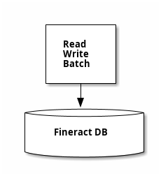

#### Configuring instance types in multi-instance setup

A common solution to dealing with the high load is to deploy 1 write and 1 batch instances and deploy multiple read instances with read replicas of the Fineract database.  
In this case, the write instance and the database will be freed from part of the load, because read request will use the separated read instance and its read replica database.

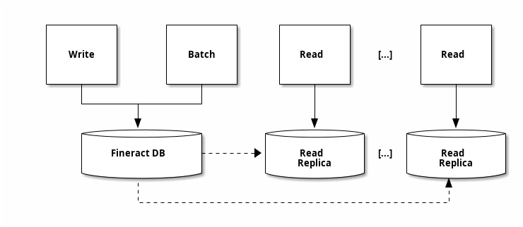

Also a common scenario when Close of Business jobs are running and Fineract has to deal with a high amount of processes.  
(In a future release) Fineract (will be) is able to run this CoB jobs in batches.  
In multi-instances environment these CoB jobs can run on multiple batch instances and they don’t have any impact on the performance of the read and write processes.  
The best practice is to deploy 1 master batch instance and multiple worker batch instances.

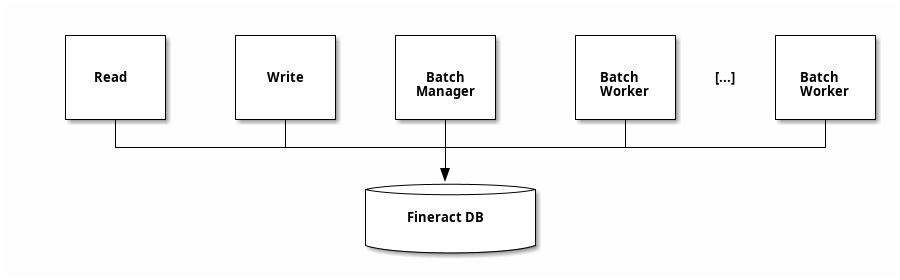

These solutions can be mixed with each other, based on the load of the Fineract deployment.

#### Configuring instance type via environment variables

The Fineract instance type is configurable via environment variables for the following 3 values:

Table 2. Environment variables

| Instance type | Environment variable |
| --- | --- |
| Read instance | FINERACT_READ_MODE_ENABLED |
| Write instance | FINERACT_WRITE_MODE_ENABLED |
| Batch instance | FINERACT_BATCH_MODE_ENABLED |

The environment variable values are booleans (true/false). The Fineract instance can be configured in any combination of these instance types, although if all 3 configurations are false, startup will fail. The default value for all 3 values is true.

The configured Fineract instance types are easily accessible via a single Spring bean, named `FineractProperties.FineractModeProperties` that has 4 methods: `isReadMode()`, `isWriteMode()`, `isBatchMode()`, `isReadOnlyMode()`

#### Liquibase Database Migration

Liquibase data migration is allowed only for write instances

#### APIs

##### Read APIs are allowed only for read and write instances

A Fineract instance is ONLY able to serve read API calls when it’s configured as a read or write instance. In batch instance mode, it won’t serve read API calls.  
If it’s a read or write instance, the read APIs will be served.  
If it’s a batch instance, the read APIs won’t be served and a proper HTTP status code will be returned.  
The distinction whether something is a read API can be decided based on the HTTP request method. If it’s a GET, we can assume it’s a read call.

##### Write APIs are allowed only for write instances

A Fineract instance is ONLY able to serve write API calls when it’s configured as a write instance. In read or batch instance mode, it won’t serve write API calls.  
If the write APIs won’t be served and a proper HTTP status code will be returned.  
If it’s a write instance, the write APIs will be served except the ones related to batch jobs.  
The distinction whether something is a write API can be decided based on the HTTP request method. If it’s non-GET, we can assume it’s a write call. Also, the write APIs related to batch jobs (starting/stopping jobs) will not be served either.

##### Batch job APIs are allowed only for batch instances

A Fineract instance is ONLY able to serve batch API calls when it’s configured as a batch instance. In read or write instance mode, it won’t serve batch API calls.  
If the batch APIs won’t be served and a proper HTTP status code will be returned.  
If it’s a batch instance, the batch APIs will be served.

#### Batch jobs

##### Batch job scheduling is allowed only for batch instances

Batch jobs are scheduled only if the Fineract instance running as a batch instance

#### Read-only instance type restrictions

If the read mode is enabled, but the write mode and batch mode are disabled, Fineract instance runs in read-only mode.

##### Events are disabled for read-only instances

When a Fineract instance is running in read-only mode, all event receiving/sending will be disabled.

##### Read-only tenant connection support

With read separation, there’s a possibility to use read-only database connections for read-only instances.  
If the instance is read-only , the DataSource connection used for the tenant will be read-only.  
If the instance is read-only and the configuration for the read-only datasource is not set, the application startup will fail.

#### Batch-only instance type restrictions

If the batch mode is enabled, but the read mode and write mode are disabled, Fineract instance runs in batch-only mode.

##### Receiving events is disabled for batch-only instances

When a Fineract instance is running as batch, event receiving will be disabled while sending events will be still possible since the batch jobs are potentially generating business events.

### Kubernetes

In a scaled Kubernetes environment where multiple Fineract instances are deployed, doing the database migrations properly is essential.

Fineract provides a way to run only the Liquibase migrations instead of starting up the whole application server so that you can easily do the migrations before actually upgrading a Fineract instance.

The `FINERACT_LIQUIBASE_ENABLED` flag controls whether Liquibase is enabled or not. For regular read/write/batch manager/batch worker instances this should be disabled.

There’s a special Spring profile that should be enabled for running Liquibase only. In can be done via `SPRING_PROFILES_ACTIVE` environment variable. The profile name is `liquibase-only`. At the end of the migration process, the application will exit.

For the instance running the Liquibase migrations, the profile should be activated.

### AWS

TBD

### Google Cloud

The www.fineract.dev demo server runs on Google Cloud.

[The Running Fineract.dev, SRE style presentation](https://docs.google.com/presentation/d/1-VP4bNkc5kZ3B0yme_vYLiY1qpswnfz8ainnX5fp3l8/) given at *ApacheCon 2020* has some related background.

### Apache Software Foundation Infrastructure

We can order a server from Apache’s infrastructure team and deploy a demo instance…

TBD

## Architecture

This document captures the major architectural decisions in platform. The purpose of the document is to provide a guide to the overall structure of the platform; where it fits in the overall context of an MIS solution and its internals so that contributors can more effectively understand how changes that they are considering can be made, and the consequences of those changes.

The target audience for this report is both system integrators (who will use the document to gain an understanding of the structure of the platform and its design rationale) and platform contributors who will use the document to reason about future changes and who will update the document as the system evolves.

### History

#### The Idea

Fineract was an idea born out of a wish to create and deploy technology that allows the microfinance industry to scale. The goal is to:

- Produce a gold standard management information system suitable for microfinance operations
- Acts as the basis of a platform for microfinance
- Open source, owned and driven by member organisations in the community
- Enabling potential for eco-system of providers located near to MFIs

#### Timeline

- 2006: Project initiated by Grameen Foundation
- Late 2011: Grameen Foundation handed over full responsibility to open source community.
- 2012: Mifos X platform started. Previous members of project come together under the name of Community for Open Source Microfinance (COSM / OpenMF)
- 2013: COSM / OpenMF officially rebranded to Mifos Initiative and receive US 501c3 status.
- 2016: Fineract 1.x began incubation at Apache

### Resources

- Project URL is github.com/apache/fineract
- Issue tracker is issues.apache.org/jira/projects/FINERACT/summary
- Download from fineract.apache.org/

### System Overview

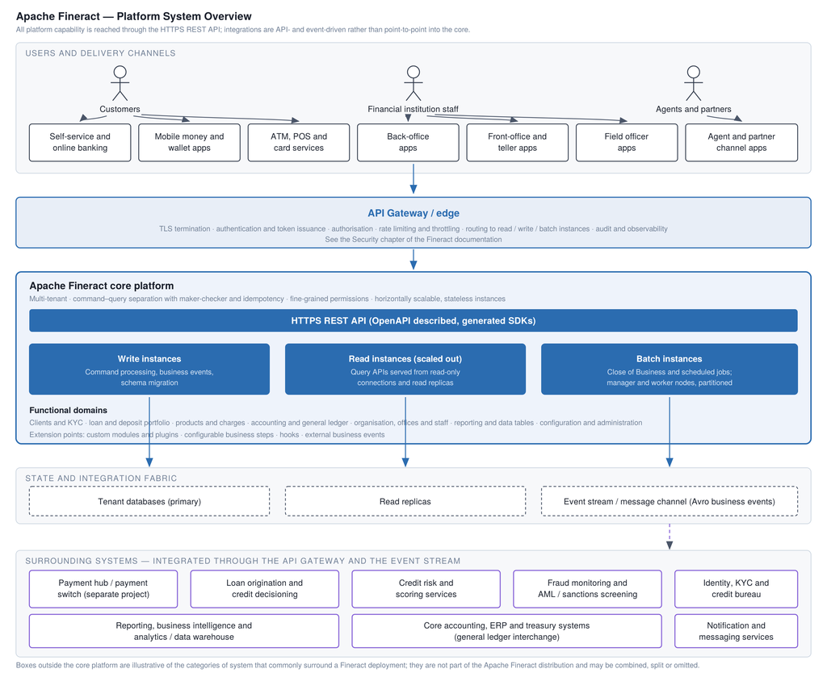

Figure 1. Platform System Overview

Apache Fineract is the core engine of a financial institution’s information  
system. It can be used by non-banks or banks.

It holds the clients, accounts, products, transactions and ledger, and  
it exposes every one of those capabilities through a single HTTPS REST API.  
Nothing in the platform is reachable by any other route: there is no alternate  
back door for a favoured channel, and no private interface reserved for a  
bundled front end.

Fineract is a headless application.

#### Channels and applications

Financial institutions reach their customers through many channels at once, and  
the mix differs by institution and by market. A customer may walk into a branch  
and transact with a teller; organise into a group or centre that meets a field  
officer at an agreed time and place; use a self-service portal or mobile  
application; transact over an ATM, point-of-sale or card network the institution  
participates in; use a mobile money or wallet service; or deal with a third-party  
agent who sells the institution’s products alongside others.

Each of these is served by a third party application, and those applications are the  
diagram’s top band. The grouping shown is illustrative rather than prescriptive.

#### The API gateway

In a production deployment, clients apps do not address Fineract instances directly.  
They address an API gateway or edge layer that sits in front of the platform and  
carries the concerns that belong at the perimeter:

- TLS termination with managed, automatically rotating certificates — Fineract  
  enforces HTTPS and ships a self-signed certificate for localhost development  
  only;
- authentication and token issuance, and coarse authorisation, ahead of the  
  platform’s own fine-grained permission checks;
- rate limiting, throttling and request size limits;
- routing of requests to the appropriate instance type (see below);
- a single point for edge audit logging, tracing and observability.

See the **Security** chapter for the authentication schemes the platform supports  
and for deployment guidance on the proxy layer.

#### Instance types and scaling

A Fineract deployment is not a single process. Because reads and writes are  
separated in the architecture, the same binary can be started in three instance  
types, enabled independently by configuration:

| Write instances | Serve the state-changing APIs. Commands pass through the command pipeline, which gives audit, maker-checker and idempotency. Business events are raised here, and database schema migration runs only on… |
| --- | --- |
| Read instances | Serve the query APIs, and may be scaled out horizontally against read replicas, using read-only database connections. This is the usual way to take query load off the primary. |
| Batch instances | Run the scheduled and Close of Business work, including partitioned jobs distributed across manager and worker nodes. |

In a single-instance deployment all three are enabled together, which is the  
default and requires no configuration. A common scaled topology is one write  
instance, one or more batch instances, and several read instances backed by read  
replicas. The **Deployment** chapter covers the configuration in detail.

#### State and integration fabric

Beneath the instances sit the tenant databases. Fineract is multi-tenant by  
design, isolating each institution’s data in its own database or schema, which  
makes it equally suitable for a single local installation and for a  
Software-as-a-Service offering.

Alongside the databases, the reliable event framework publishes business events  
to a downstream message channel in a standardised Avro format, with ordering and  
at-least-once delivery guarantees. Events are the second integration surface  
after the API, and they are what allow surrounding systems to react to what  
happens in the core without polling it.

#### Surrounding systems

A core banking platform (or loan management system with core ledger) is never deployed alone.  
Around Fineract an institution typically operates a set of specialised systems, and the lower band of the  
diagram names the categories most often seen:

- a payment hub or payment switch, connecting the institution to domestic  
  instant payment schemes, card networks and mobile money operators;
- loan origination and credit decisioning, where applications are captured,  
  underwritten and approved before an account is opened in the core;
- credit risk and scoring services, including alternative-data scoring models;
- fraud monitoring and AML, sanctions and transaction screening;
- identity, KYC and credit bureau services;
- reporting, business intelligence and analytics, usually reading from a data  
  warehouse fed from the replicas or the event stream rather than querying the  
  transactional database;
- core accounting, ERP and treasury systems, which exchange general ledger  
  postings with the platform;
- notification and messaging services.

None of these other components or systems are part of the Apache Fineract core distribution.  
They are separate products or projects, commercial or open source, and an institution may combine  
several of them, split one across vendors, or operate without some of them  
entirely. They are drawn here because the shape of a real deployment is not  
legible without them — and because the way they attach matters. Each integrates  
through the API gateway, through the event stream, or both. None of them reaches  
into the platform’s database, and none of them is a privileged component.

For capabilities that belong inside a transaction rather than beside it, the  
platform offers extension points instead of integration: custom modules and  
plugin JARs, configurable business steps within jobs such as Close of Business,  
hooks, and custom command handlers. The **Custom Modules** chapter describes these.

#### What this means for an implementer

1. **The API is the contract.** It is described by an OpenAPI descriptor from which  
   client SDKs are generated, and backward compatibility is enforced  
   automatically on every change. Build against it with confidence.
2. **The core stays core.** Resist the temptation to add additional origination workflow,  
   scoring models, channel-specific logic or reporting pipelines inside the  
   platform. They belong in the surrounding systems, where they can evolve on  
   their own release cycle.
3. **Scale the parts that need it.** Query load, write load and batch load have  
   different profiles. Separating the instance types is usually a cheaper answer.

### Functional Overview

As ALL capabilities of the platform are exposed through an API, The API docs are the best place to view a detailed breakdown of what the platform does. See online API Documentation.

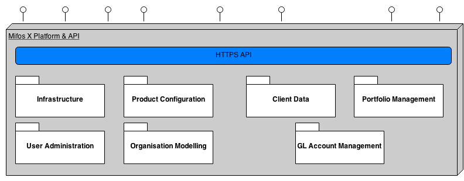

Figure 2. Platform Functional Overview

At a higher level though we see the capabilities fall into the following categories:

- Infrastructure
  - Codes
  - Extensible Data Tables
  - Reporting
- User Administration
  - Users
  - Roles
  - Permissions
- Organisation Modelling
  - Offices
  - Staff
  - Currency
- Product Configuration
  - Charges
  - Loan Products
  - Deposit Products
- Client Data
  - Know Your Client (KYC)
- Portfolio Management
  - Loan Accounts
  - Deposit Accounts
  - Client/Groups
- GL Account Management
  - Chart of Accounts
  - General Ledger

### Principles

#### RESTful API

The platform exposes all its functionality via a **practically-RESTful API**, that communicates using JSON.

We use the term **practically-RESTful** in order to make it clear we are not trying to be fully REST compliant but still maintain important RESTful attributes like:

- Stateless: platform maintains no conversational or session-based state. The result of this is ability to scale horizontally with ease.
- Resource-oriented: API is focussed around set of resources using HTTP vocabulary and conventions e.g GET, PUT, POST, DELETE, HTTP status codes. This results in a simple and consistent API for clients.

See online API Documentation for more detail.

#### Multi-tenanted

The Fineract platform has been developed with support for multi-tenancy at the core of its design. This means that it is just as easy to use the platform for Software-as-a-Service (SaaS) type offerings as it is for local installations.

The platform uses an approach that isolates an FIs data per database/schema (See Separate Databases and Shared Database, Separate Schemas).

#### Extensible

Whilst each tenant will have a set of core tables, the platform tables can be extended in different ways for each tenant through the use of Data tables functionality.

#### Command Query Separation

We separate **commands** (that change data) from **queries** (that read data).

Why? There are numerous reasons for choosing this approach which at present is not an attempt at full blown CQRS. The main advantages at present are:

- State changing commands are persisted providing an audit of all state changes.
- Used to support a general approach to **maker-checker**.
- State changing commands use the Object-Oriented paradigm (and hence ORM) whilst querys can stay in the data paradigm.

#### Maker-Checker

Also known as **four-eyes principal**. Enables apps to support a maker-checker style workflow process. Commands that pass validation will be persisted. Maker-checker can be enabled/disabled at fine-grained level for any state changing API.  
Fine grained access control

A fine grained permission is associated with each API. Administrators have fine grained control over what roles or users have access to.

#### Package Structure

The intention is for platform code to be packaged in a vertical slice way (as opposed to layers).  
Source code starts from github.com/apache/fineract/tree/develop/fineract-provider/src/main/java/org/apache/fineract

- accounting
- useradministration
- infrastructure
- portfolio
  - charge
  - client
  - fund
  - loanaccount
- accounting

Within each vertical slice is some common packaging structure:

- api - XXXApiResource.java - REST api implementation files
- handler - XXXCommandHandler.java - specific handlers invoked
- service - contains read + write services for functional area
- domain - OO concepts for the functional area
- data - Data concepts for the area
- serialization - ability to convert from/to API JSON for functional area

### Design Overview

|  | The implementation of the platform code to process commands through handlers whilst supporting maker-checker and authorisation checks is a little bit convoluted at present and is an area pin-pointed f… |
| --- | --- |

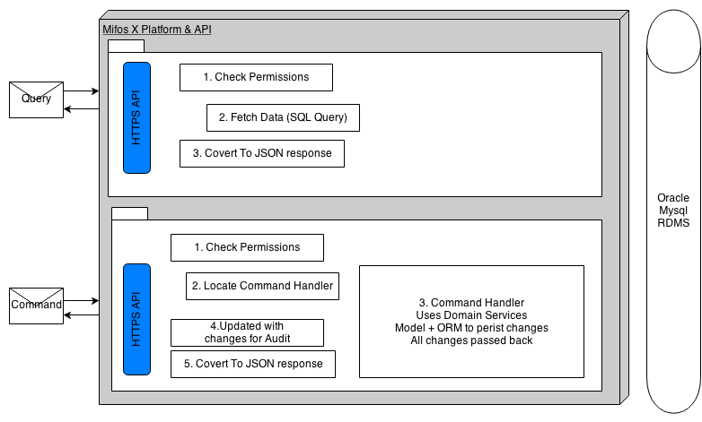

Figure 3. CQRS

Taking into account example shown above for the **users** resource.

- Query: GET /users
- HTTPS API: retrieveAll method on **org.apache.fineract.useradministration.api.UsersApiResource** invoked
- UsersApiResource.retrieveAll: Check user has permission to access this resources data.
- UsersApiResource.retrieveAll: Use 'read service' to fetch all users data ('read services' execute simple SQL queries against Database using JDBC)
- UsersApiResource.retrieveAll: Data returned to converted into JSON response
- Command: POST /users (Note: data passed in request body)
- HTTPS API: create method on org.apache.fineract.useradministration.api.UsersApiResource invoked

UsersApiResource.create

```
                .withJson(apiRequestBodyAsJson) //
                .build();

        final CommandProcessingResult result = this.commandsSourceWritePlatformService.logCommandSource(commandRequest);

        return this.toApiJsonSerializer.serialize(result);
    }

    @PUT
    @Path("{userId}")
    @Operation(summary = "Update a User", operationId = "updateUser", tags = { "Users" }, description = "Updates the user")
    @AlternativeOperationId("update_26")
    @RequestBody(required = true, content = @Content(schema = @Schema(implementation = UsersApiResourceSwagger.PutUsersUserIdRequest.class)))
    @ApiResponses({
            @ApiResponse(responseCode = "200", description = "OK", content = @Content(schema = @Schema(implementation = UsersApiResourceSwagger.PutUsersUserIdResponse.class))) })
    @Consumes({ MediaType.APPLICATION_JSON })
    @Produces({ MediaType.APPLICATION_JSON })
    public String update(@PathParam("userId") @Parameter(description = "userId") final Long userId,
            @Parameter(hidden = true) final String apiRequestBodyAsJson) {

        final CommandWrapper commandRequest = new CommandWrapperBuilder() //
```

Create a CommandWrapper object that represents this create user command and JSON request body. Pass off responsibility for processing to PortfolioCommandSourceWritePlatformService.logCommandSource

```
            isApprovedByChecker = true; // set to true in case permissions have
                                        // been maker-checker enabled by
                                        // accident.
        } else {
            final String taskPermission = wrapper.getTaskPermissionName();
            if (isCheckerOnly(currentUser, taskPermission)) {
                final CommandSource pendingCommand = findPendingCommand(wrapper)
                        .orElseThrow(() -> new MakerCheckerCheckerOnlyInitiationException(taskPermission));
                return approveEntry(pendingCommand.getId());
            }
            currentUser.validateHasPermissionTo(taskPermission);
            if (configurationService.isMakerCheckerEnabledForTask(taskPermission) && !currentUser.isCheckerSuperUser()
                    && findPendingCommand(wrapper).isPresent()) {
                throw new MakerCheckerDuplicatePendingSubmissionException(wrapper.actionName(), wrapper.entityName());
            }
        }
        validateIsUpdateAllowed();

        final String json = wrapper.getJson();
        final JsonElement parsedCommand = this.fromApiJsonHelper.parse(json);
        JsonCommand command = JsonCommand.from(json, parsedCommand, this.fromApiJsonHelper, wrapper.getEntityName(), wrapper.getEntityId(),
                wrapper.getSubentityId(), wrapper.getGroupId(), wrapper.getClientId(), wrapper.getLoanId(), wrapper.getSavingsId(),
                wrapper.getTransactionId(), wrapper.getHref(), wrapper.getProductId(), wrapper.getCreditBureauId(),
                wrapper.getOrganisationCreditBureauId(), wrapper.getJobName(), wrapper.getLoanExternalId());

        return this.processAndLogCommandService.executeCommand(wrapper, command, isApprovedByChecker);
    }

    @Override
    public CommandProcessingResult approveEntry(final Long makerCheckerId) {
        final CommandSource commandSourceInput = validateMakerCheckerTransaction(makerCheckerId);
        validateIsUpdateAllowed();

        final CommandWrapper wrapper = CommandWrapper.fromExistingCommand(makerCheckerId, commandSourceInput.getActionName(),
                commandSourceInput.getEntityName(), commandSourceInput.getResourceId(), commandSourceInput.getSubResourceId(),
                commandSourceInput.getResourceGetUrl(), commandSourceInput.getProductId(), commandSourceInput.getOfficeId(),
                commandSourceInput.getGroupId(), commandSourceInput.getClientId(), commandSourceInput.getLoanId(),
                commandSourceInput.getSavingsId(), commandSourceInput.getTransactionId(), commandSourceInput.getCreditBureauId(),
                commandSourceInput.getOrganisationCreditBureauId(), commandSourceInput.getIdempotencyKey(),
                commandSourceInput.getLoanExternalId());
        final JsonElement parsedCommand = this.fromApiJsonHelper.parse(commandSourceInput.getCommandAsJson());
        final JsonCommand command = JsonCommand.fromExistingCommand(makerCheckerId, commandSourceInput.getCommandAsJson(), parsedCommand,
                this.fromApiJsonHelper, commandSourceInput.getEntityName(), commandSourceInput.getResourceId(),
                commandSourceInput.getSubResourceId(), commandSourceInput.getGroupId(), commandSourceInput.getClientId(),
                commandSourceInput.getLoanId(), commandSourceInput.getSavingsId(), commandSourceInput.getTransactionId(),
                commandSourceInput.getResourceGetUrl(), commandSourceInput.getProductId(), commandSourceInput.getCreditBureauId(),
                commandSourceInput.getOrganisationCreditBureauId(), commandSourceInput.getJobName(),
                commandSourceInput.getLoanExternalId());

        return this.processAndLogCommandService.executeCommand(wrapper, command, true);
    }

    @Transactional
    @Override
    public Long deleteEntry(final Long makerCheckerId) {

        validateMakerCheckerTransaction(makerCheckerId);
        validateIsUpdateAllowed();

        this.commandSourceRepository.deleteById(makerCheckerId);
```

Check user has permission for this action. if ok, a) parse the json request body, b) create a JsonCommand object to wrap the command details, c) use CommandProcessingService to handle command

```
    private final RetryConfigurationAssembler retryConfigurationAssembler;

    private final FineractRequestContextHolder fineractRequestContextHolder;
    private final Gson gson = GoogleGsonSerializerHelper.createSimpleGson();

    private CommandProcessingResult executeWithRetry(CommandExecutionContext executionContext) {
        try {
            if (!BatchRequestContextHolder.isEnclosingTransaction()) {
                return retryConfigurationAssembler.getRetryConfigurationForExecuteCommand()
                        .executeSupplier(() -> executeCommandAttempt(executionContext));
            }
            return executeCommandAttempt(executionContext);
        } catch (RollbackTransactionNotApprovedException e) {
            throw e;
        } catch (RuntimeException e) {
            RuntimeException mappable = ErrorHandler.getMappable(e);
            persistFinalErrorResult(executionContext, mappable);
            throw mappable;
        }
    }

    @Override
    public CommandProcessingResult executeCommand(final CommandWrapper wrapper, final JsonCommand command,
            final boolean isApprovedByChecker) {
        return executeWithRetry(new CommandExecutionContext(wrapper, command, isApprovedByChecker));
    }

    private CommandProcessingResult executeCommandAttempt(CommandExecutionContext executionContext) {
        // Do not store the idempotency key because of the exception handling
        setIdempotencyKeyStoreFlag(false);

        CommandWrapper wrapper = executionContext.wrapper();
        JsonCommand command = executionContext.command();
        Long commandId = (Long) fineractRequestContextHolder.getAttribute(COMMAND_SOURCE_ID, null);
        boolean isRetry = commandId != null;
        boolean isEnclosingTransaction = BatchRequestContextHolder.isEnclosingTransaction();
        executionContext.setEnclosingTransaction(isEnclosingTransaction);

        CommandSource commandSource = null;
        String idempotencyKey;
        if (isRetry) {
            commandSource = commandSourceService.getCommandSource(commandId);
            idempotencyKey = commandSource.getIdempotencyKey();
        } else if ((commandId = command.commandId()) != null) { // action on the command itself
            commandSource = commandSourceService.getCommandSource(commandId);
            idempotencyKey = commandSource.getIdempotencyKey();
        } else {
            idempotencyKey = idempotencyKeyResolver.resolve(wrapper);
        }
        exceptionWhenTheRequestAlreadyProcessed(wrapper, idempotencyKey, isRetry);

        AppUser user = context.authenticatedUser(wrapper);
        if (commandSource == null) {
            if (isEnclosingTransaction) {
                commandSource = commandSourceService.getInitialCommandSource(wrapper, command, user, idempotencyKey);
            } else {
                commandSource = commandSourceService.saveInitial(wrapper, command, user, idempotencyKey);
                commandId = commandSource.getId();
            }
        }
        executionContext.setCommandSource(commandSource);
        if (commandId != null) {
            storeCommandIdInContext(commandSource); // Store command id as a request attribute
        }

        setIdempotencyKeyStoreFlag(true);
```

|  | if a RollbackTransactionAsCommandIsNotApprovedByCheckerException occurs at this point. The original transaction will of been aborted and we only log an entry for the command in the audit table setting… |
| --- | --- |

- Check that if maker-checker configuration enabled for this action. If yes and this is not a 'checker' approving the command - rollback at the end. We rollback at the end in order to test if the command will pass 'domain validation' which requires commit to database for full check.
- findCommandHandler - Find the correct Handler to process this command.
- Process command using handler (In transactional scope).
- CommandSource object created/updated with all details for logging to 'm_portfolio_command_source' table.
- In update scenario, we check to see if there where really any changes/updates. If so only JSON for changes is stored in audit log.

### Persistence

TBD

#### Database support

Fineract officially supports PostgreSQL.

[MySQL and MariaDB support exists and is deprecated — it will eventually be removed entirely](https://cwiki.apache.org/confluence/display/FINERACT/FSIP-9%3A+Standardize+on+PostgreSQL).

The platform differentiates between these database types in certain cases when there’s a need to use some database specific tooling. To do so, the platform examines the JDBC driver used for running the platform and tries to determine which database is being used.

| **JDBC driver class name** | **Resolved database type** |
| --- | --- |
| `org.mariadb.jdbc.Driver` | MySQL |
| `com.mysql.jdbc.Driver` | MySQL |
| `org.postgresql.Driver` | PostgreSQL |

The actual code can be found in the `DatabaseTypeResolver` class.

#### Tenant database security

The tenant database schema password is stored in the `tenant_server_connections` table in the tenant database. The password and the read only schema password are encrypted using the `fineract.tenant.master-password` property. By default, the database property will be encrypted in the first start from a plain text.

When you want to generate a new encrypted password, you can use the `org.apache.fineract.infrastructure.core.service.database.DatabasePasswordEncryptor` class.

##### Database password encryption usage

```
java -cp fineract-provider.jar \
  -Dloader.main=org.apache.fineract.infrastructure.core.service.database.DatabasePasswordEncryptor \
  org.springframework.boot.loader.PropertiesLauncher \
  <masterPassword> \
  <plainPassword>
```

For example:

```
java -cp fineract-provider-0.0.0-48f7e315.jar \
  -Dloader.main=org.apache.fineract.infrastructure.core.service.database.DatabasePasswordEncryptor \
  org.springframework.boot.loader.PropertiesLauncher \
  fineract-master-password \
  fineract-tenant-password
The encrypted password: VLwGl7vOP/q275ZTku+PNGWnGwW4mzzNHSNaO9Pr67WT5/NZMpBr9tGYYiYsqwL1eRew2jl7O3/N1EFbLlXhSA==
```

#### Data-access layer

The data-access layer of Fineract is implemented by using JPA (Java Persistence API) with the EclipseLink provider.  
Despite the fact that JPA is used quite extensively in the system, there are cases where the performance is a key element for an operation therefore you can easily find native SQLs as well.

The data-access layer of Fineract is compatible with different databases. Since a lot of the native queries are using specific database functions, a wrapper class - `DatabaseSpecificSQLGenerator` - has been introduced to handle these database specifics. Whenever there’s a need to rely on new database level functions, make sure to extend this class and implement the specific functions provided by the database.

Fineract has been developed for 10+ years by the community and unfortunately there are places where entity relationships are configured with `EAGER` fetching strategy. This must not confuse anybody. The long-term goal is to use the `LAZY` fetching strategy for every single relationship. If you’re about to introduce a new one, make sure to use `LAZY` as a fetching strategy, otherwise your PR will be rejected.

#### Database schema migration

As for every system, the database structure will and need to evolve over time. Fineract is no different. Originally for Fineract, Flyway was used until Fineract 1.6.x.

After 1.6.x, PostgreSQL support was added to the platform hence there was a need to make the data-access layer and the schema migration as database independent as possible. Because of that, from Fineract 1.7.0, Flyway is not used anymore but Liquibase is.

Some of the changesets in the Liquibase changelogs have database specifics into it but they only run for the relevant databases. This is controller by Liquibase contexts.

The currently available Liquibase contexts are:

- `mysql` - only set when the database is a MySQL compatible database (e.g. MariaDB)
- `postgresql` - only set when the database is a PostgreSQL database
- configured Spring active profiles
- `tenant_store_db` - only set when the database migration runs the Tenant Store upgrade
- `tenant_db` - only set when the database migration runs the Tenant upgrade
- `initial_switch` - this is a technical context and should **NOT** be used

The switch from Flyway (1.6.x) to Liquibase (1.7.x) was planned to be as smooth as possible so there’s no need for manual work hence the behavior is described as following:

- If the database is empty, Liquibase will create the database schema from scratch
- If the database contains the latest Fineract 1.6.x database structure which was previously migrated with Flyway. Liquibase will seamlessly upgrade it to the latest version. Note: the Flyway related 2 database tables are left as they are and are not deleted.
- If the database contains an earlier version of the database structure than Fineract 1.6.x. Liquibase will **NOT** do anything and **will fail the application during startup**. The proper approach in this case is to first upgrade your application version to the latest Fineract 1.6.x so that the latest Flyway changes are executed and then upgrade to the newer Fineract version where Liquibase will seamlessly take over the database upgrades.

##### Troubleshooting

1. During upgrade from Fineract 1.5.0 to 1.6.0, Liquibase fails

   After dropping the flyway migrations table (schema_version), Liquibase runs its  
   own migrations which fails (in recreating tables which already exist) because  
   we are aiming to re-use DB with existing data from Fineract 1.5.0.

   Solution: The latest release version (1.6.0) doesn’t have Liquibase at all, it  
   still runs Flyway migrations. Only the develop branch (later to be 1.7.0) got  
   switched to Liquibase. Do not pull the develop before upgrading your instance.

   Make sure first you upgrade your instance (aka database schema with Fineract 1.6.0).  
   Then upgrade with the current develop branch. Check if some migration scripts  
   did not run which led to some operations failing due to slight differences in  
   schema. Try with running the missing migrations manually.

   Note: develop is considered unstable until released.
2. Upgrading database from MySQL 5.7 as advised to Maria DB 10.6, fails. If we  
   use data from version 18.03.01 it fails to migrate the data. If we use databases  
   running on 1.5.0 release it completes the startup but the system login fails.

   Solution: A database upgrade is separate thing to take care of.
3. We are getting

   ```
   ScehmaUpgradeNeededException: Make sure to upgrade to Fineract

   1.6 first and then to a newer version
   ```

   error while upgrading to `tag 1.6`.

   1.6 version shouldn’t include Liquibase. It will only be released after 1.6.  
   Make sure Liquibase is dropping `schema_version` table, as there is no Flyway  
   it is not required. Drop Flyway and use Liquibase for both migrations and  
   database independence. In case, if you still get errors, you can use git SHA  
   `746c589a6e809b33d68c0596930fcaa7338d5270` and Flyway migration will be done to  
   the latest.

   ```
   TENANT_LATEST_FLYWAY_VERSION = 392;
   TENANT_LATEST_FLYWAY_SCRIPT_NAME =
   "V392__interest_recovery_conf_for_rescedule.sql";
   TENANT_LATEST_FLYWAY_SCRIPT_CHECKSUM = 1102395052;
   ```

### Idempotency

Idempotency is the way to make sure your specific action is only executed once.  
For example, if you have a button that is supposed to send a repayment, you don’t want to repayment twice if the user clicks the button twice. Idempotency is a way to make sure that the action is only executed once.

There are two ways to use idempotency:

- HTTP Request with idempotency key header
- Batch request with batch item header

#### How it works

The `idempotency key` with `action name` and `entity name` is unique, and identify a specific command in the system.  
If no idempotency key is assigned to the request, the system will generate one for you.

1. User send a request
2. The system checks there are already executed commands with the same `idempotency key` and `action name` and `entity name`
3. The action based on the result of the check
   - If the request is completed the system return with the already generated result
   - If not completed, return HTTP 409 response
   - If the request is not completed, we process the requests and store the results in the database

#### Idempotency in HTTP requests

To achieve idempotency in HTTP requests, you can use the HTTP header from `fineract.idempotency-key-header-name` configuration variables (default `Idemptency-Key`). This header is a unique identifier for the request. If you send the same request twice, the second request will be ignored and the response from the first request will be returned.

#### Idempotency in Batch requests

In batch requests, you can set the idempotency key for every batch item, in the batch item `header` fields. The header key is from `fineract.idempotency-key-header-name` configuration variables (default `Idemptency-Key`).

#### Result of the request

- When the request is already executed and completed, the system will return a `x-served-from-cache` header with the value `true` in the response and return the original request body.
- When the request is already executed but still not completed, the system will return to HTTP 409 error code
- When the request is not executed, the system runs it normally and stores the result in the date

### Validation

#### Programmatic

Use the [DataValidatorBuilder](https://github.com/apache/fineract/search?q=%22class+DataValidatorBuilder%22), e.g. like so:

```
new DataValidatorBuilder().resource("fileUpload")
    .reset().parameter("Content-Length").value(contentLength).notBlank().integerGreaterThanNumber(0)
    .reset().parameter("FormDataContentDisposition").value(fileDetails).notNull()
    .throwValidationErrors();
```

Such code is often encapsulated in [`*Validator`](https://github.com/apache/fineract/search?q=Validator) classes (if more than a few lines, and/or reused from several places; avoid copy/paste), like so:

```
public class YourThingValidator {

    public void validate(YourThing thing) {
        new DataValidatorBuilder().resource("yourThing")
        ...
        .throwValidationErrors();
    }
}
```

#### Declarative

FINERACT-1229 is an open issue about adopting Bean Validation for *declarative* instead of *programmatic* (as above) validation. Contributions welcome!

### Batch execution and jobs

Just like any financial system, Fineract also has batch jobs to achieve some processing on the data that’s stored in the system.

The batch jobs in Fineract are implemented using [Spring Batch](https://docs.spring.io/spring-batch/docs/current/reference/html/). In addition to the Spring Batch ecosystem, the automatic scheduling is done by the [Quartz Scheduler](http://www.quartz-scheduler.org/) but it’s also possible to trigger batch jobs via regular APIs.

#### Glossary

| **Job** | A Job is an object that encapsulates an entire batch process. |
| --- | --- |
| **Step** | A Step is an object that encapsulates an independent phase of a Job. |
| **Chunk oriented processing** | Chunk oriented processing refers to reading the data one at a time and creating 'chunks' that are written out within a transaction boundary. |
| **Partitioning** | Partitioning refers to the high-level idea of dividing your data into so called partitions and distributing the individual partitions among Workers. The splitting of data and pushing work to Workers i… |
| **Remote partitioning** | Remote partitioning is a specialized partitioning concept. It refers to the idea of distributing the partitions among multiple JVMs mainly by using a messaging middleware. |
| **Manager node** | The Manager node is one of the objects taking a huge part when using partitioning. The Manager node is responsible for dividing the dataset into partitions and keeping track of all the divided partiti… |
| **Worker node** | A Worker node is the other important party in the context of partitioning. The Worker node is the one executing the work needed for a single partition. |

#### Batch jobs in Fineract

##### Types of jobs

The jobs in Fineract can be divided into 2 categories:

- Normal batch jobs
- Partitionable batch jobs

Most of the jobs are normal batch jobs with limited scalability because Fineract is still passing through the evolution on making most of them capable to process a high-volume of data.

##### List of jobs

| **Job name** | **Active by default** | **Partitionable** | **Description** |
| --- | --- | --- | --- |
| LOAN_CLOSE_OF_BUSINESS | No | Yes | TBD |

#### Batch job execution

##### State management

State management for the batch jobs is done by the Spring Batch provided state management. The data model consists of the following database structure:

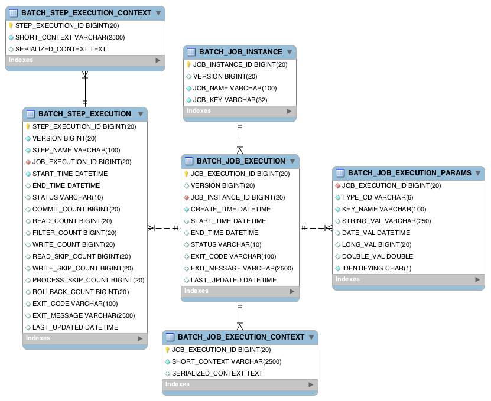

The corresponding database migration scripts are shipped with the Spring Batch core module under the `org.springframework.batch.core` package. They are only available as native scripts and are named as `schema-.sql` where is the short name of the database platform. For MySQL it’s called `schema-mysql.sql` and for PostgreSQL it’s called `schema-postgresql.sql`.  
When Fineract is started, the database dependent schema SQL script will be picked up according to the datasource configurations.

##### Chunk oriented processing

Chunking data has not been easier. Spring Batch does a really good job at providing this capability.

In order to save resources when starting/committing/rollbacking transactions for every single processed item, chunking shall be used. That way, it’s possible to mark the transaction boundaries for a single processed chunk instead of a single item processing. The image below describes the flow with a very simplistic example.

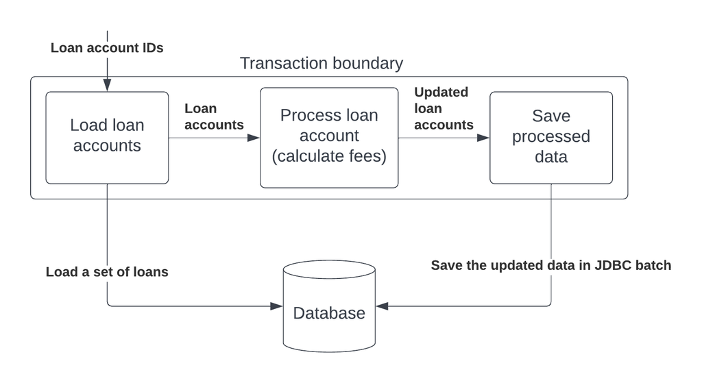

In addition to not opening a lot of transactions, the processing could also benefit from JDBC batching. The last step - writing the result into the database - collects all the processed items and then writes it to the database; both for MySQL and PostgreSQL (the databases supported by Fineract) are capable of grouping multiple DML (INSERT/UPDATE/DELETE) statements and sending them in one round-trip, optimizing the data being sent over the network and granting the possibility to the underlying database engine to enhance the processing.

##### Remote partitioning

Spring Batch provides a really nice way to do remote partitioning. The 2 type of objects in this setup is a manager node - who splits and distributes the work - and a number of worker nodes - who picks up the work.

In remote partitioning, the worker instances are receiving the work via a messaging system as soon as the manager splits up the work into smaller pieces.

Remote partitioning could be done 2 ways in terms of keeping the job state up-to-date. The main difference between the two is how the manager is notified about partition completions.

One way is that they share the same database. When the worker does something to a partition - for example picks it up for processing - it updates the state of that partition in the database. In the meantime, the manager regularly polls the database until all partitions are processed. This is visualized in the below diagram.

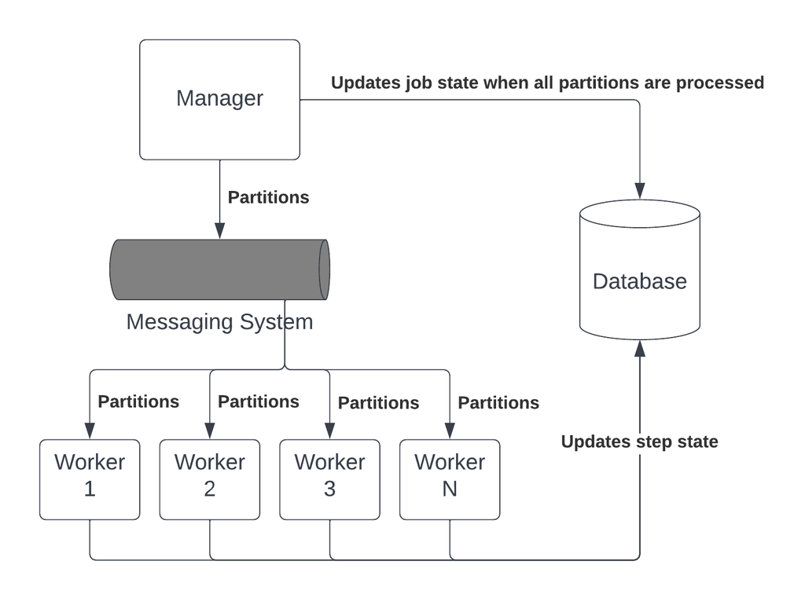

An alternative approach to this - when the database is not intended to be shared between manager and workers - is to use a messaging system (could be the same as for distributing the work) and the workers could send back a message to the manager instance, therefore notifying it about failure/completion. Then the manager can simply keep the database state up-to-date.

Even though the alternative solution decouples the workers even better, we thought it’s not necessary to add the complexity of handling reply message channel to the manager.

Also, please note that the partitioned job execution is multitenant meaning that the workers will receive which tenant it should do the processing for.

###### Supported message channels

For remote partitioning, the following message channels are supported by Fineract:

- Any JMS compatible message channels (ActiveMQ, Amazon MQ, etc)
- Apache Kafka

###### Fault-tolerance scenarios

There are multiple fault tolerance use-cases that this solution must and will support:

1. If the manager fails during partitioning
2. If the manager completes the partitioning and the partition messages are sent to the broker but while the manager is waiting for the workers to finish, the manager fails
3. If the manager runs properly and during a partition processing a worker instance fails

In case of scenario 1), the simple solution is to re-trigger the job via API or via the Quartz scheduler.

In case of scenario 2), there’s no out-of-the-box solution by Spring Batch. Although there’s a custom mechanism in place that’ll resume the job upon restarting the manager. There are 2 cases in the context of this scenario:

- If all the partitions have been successfully processed by workers
- If not all the partitions have been processed by the workers

In the first case, we’ll simply mark the stuck job as `FAILED` along with it’s partitioning step and instruct Spring Batch to restart the job. The behavior in this case will be that Spring Batch will spawn a new job execution but will notice that the partitions have all been completed so it’s not going to execute them once more.

In the latter case, the same will happen as for the first one but before marking the job execution as `FAILED`, we’ll wait until all partitions have been completed.

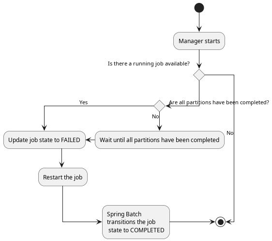

In case of scenario 3), another worker instance will take over the partition since it hasn’t been finished.

#### Configurable batch jobs

There’s another type of distinction on the batch jobs. Some of them are configurable in terms of their behavior.

The currently supported configurable batch jobs are the following:

- LOAN_CLOSE_OF_BUSINESS

The behavior of these batch jobs are configurable. There’s a new terminology we’re introducing called **business steps**.

##### Business steps

Business steps are a smaller unit of work than regular Spring Batch Steps and the two are not meant to be mixed up because there’s a large difference between them.

A Spring Batch Step’s main purpose is to decompose a bigger work into smaller ones and making sure that these smaller Steps are properly handled within a single database transaction.

In case of a business step, it’s a smaller unit of work. Business steps live **within** a Spring Batch Step. Fundamentally, they are simple classes that are implementing an interface with a single method that contains the business logic.

Here’s a very simple example:

```
public class MyCustomBusinessStep implements BusinessStep<Loan> {
    @Override
    public Loan process(Loan loan) {
        // do something
    }
}
```

```
public class LoanCOBItemProcessor implements ItemProcessor<Loan, Loan> {
    @Override
    public Loan process(Loan loan) {
        List<BusinessStep<Loan>> bSteps = getBusinessSteps();
        Loan result = loan;
        for (BusinessStep<Loan> bStep : bSteps) {
            result = bStep.process(result);
        }
        return result;
    }
}
```

##### Business step configuration

The business steps are configurable for certain jobs. The reason for that is because we want to allow the possibility for Fineract users to configure their very own business logic for generic jobs, like the Loan Close Of Business job where we want to do a formal "closing" of the loans at the end of the day.

All countries are different with a different set of regulations. However in terms of behavior, there’s no all size fits all for loan closing.

For example in the United States of America, you might need the following logic for a day closing:

1. Close fully repaid loan accounts
2. Apply penalties
3. Invoke IRS API for regulatory purposes

While in Germany it should be:

1. Close fully repaid loan accounts
2. Apply penalties
3. Do some fraud detection on the account using an external service
4. Invoke local tax authority API for regulatory purposes

These are just examples, but you get the idea.

The business steps are configurable through APIs:

Retrieving the configuration for a job:

```
GET /fineract-provider/api/v1/jobs/{jobName}/steps?tenantIdentifier={tenantId}
HTTP 200

{
  "jobName": "LOAN_CLOSE_OF_BUSINESS",
  "businessSteps": [
    {
      "stepName": "APPLY_PENALTY_FOR_OVERDUE_LOANS",
      "order": 1
    },
    {
      "stepName": "LOAN_TAGGING",
      "order": 2
    }
  ]
}
```

Updating the business step configuration for a job:

```
PUT /fineract-provider/api/v1/jobs/{jobName}/steps?tenantIdentifier={tenantId}

{
  "businessSteps": [
    {
      "stepName": "LOAN_TAGGING",
      "order": 1
    },
    {
      "stepName": "APPLY_PENALTY_FOR_OVERDUE_LOANS",
      "order": 2
    }
  ]
}
```

The business step configuration for jobs are tracked within the database in the `m_batch_business_steps` table.

#### Inline Jobs

Some jobs that work with business entities have a corresponding job that can trigger the job with a list of specified entities.  
When the Inline job gets triggered then the corresponding existing job will run in real time with the given entities as a dataset.

##### List of Inline jobs

| **Inline Job name** | **Corresponding Job** |
| --- | --- |
| LOAN_COB | LOAN_CLOSE_OF_BUSINESS |

Triggering the Inline Loan COB Job:

```
POST /fineract-provider/api/v1/jobs/LOAN_COB/inline?tenantIdentifier={tenantId}

{
  "loanIds": [
      1, 2, 3, 4, 5, 6, 7, 8, 9, 10, 11, 12, 13, 14
  ]
}
```

In this case the Loan COB job will work only with the given loan IDs.

#### Executing missed runs

The scheduler runs in memory and has no persistent job store. A cron fire that happens while Fineract is down never happens, and a fire that happens while the scheduler is suspended is vetoed. Both are lost by default.

When `fineract.job.execute-missed-runs` (environment variable `FINERACT_JOB_EXECUTE_MISSED_RUNS`, default `false`) is `true`, the scheduler replays what was missed. The `next_run_time` of a job records the first run that never happened, because a vetoed fire never advances it, and this is used as the start of the job’s trigger, so Quartz applies its own misfire handling:

- By default a job fires once, as soon as the scheduler is up, however many runs it missed.
- `Increase Business Date by 1 day` fires once per missed run, one after another, so the business date moves one day per missed run. `Increase COB Date by 1 day` fires once.
- A job never runs concurrently with itself. Fires while the scheduler is suspended are still vetoed and do not advance `next_run_time`.

The replay happens in two places:

- On boot, for every active job whose `next_run_time` is in the past. A tenant with `reset_scheduler_on_bootup` is un-suspended before its jobs are registered, so the replayed fires are not vetoed.
- On `POST /scheduler?command=start`, which registers each active job with a past `next_run_time` again in the same way and clears `is_misfired`. With the property off the existing `execute_misfired_jobs` replay is unchanged.

`next_run_time` is the instant of a Quartz fire time and is compared as an instant, so neither the tenant’s nor the JVM’s time zone changes what counts as missed. The cron expression itself is evaluated in the tenant’s time zone. The column has no zone, a `Date` is mapped with the JVM’s default zone, so keep the same default zone (the shipped images use `-Duser.timezone=UTC`) across restarts.

There is no dependency between jobs in general. The jobs that have to run in order are `Increase Business Date by 1 day`, `Increase COB Date by 1 day`, `Loan COB` and `Working Capital Loan COB`: the COB reads the COB date when it starts, so it must not start before the business date has caught up. They are in `scheduler_group` 1, which has a Quartz scheduler of its own with a single thread, so they never run concurrently. Jobs are registered by `task_priority` (highest first, then by id), and when several fires are due the one with the oldest fire time goes first, so the replayed business date runs come before the COB runs. Every other job is in `scheduler_group` 0, the shared scheduler with several threads. The group of a job cannot be changed through the API. The consequence of the single thread is that a long Loan COB delays the Working Capital COB and the next midnight fires of the group; the business date job still fires once per missed day.

A replayed run executes on the day of the catch-up, not on the day it was missed, so a job that depends on the real clock or on a business date that has not caught up yet sees the current state. Known limits:

- Periodic standing instructions lose the skipped dates, because they match the exact business date.
- Retained Earning is wrong if the business date jumps over a year end in one step.
- Jobs outside COB date their postings on the catch-up day.
- Report mailing sends duplicates after a long gap.

##### COB catch-up after a replayed COB run

A regular `Loan COB` run only closes the loans that are exactly one day behind (or have never been closed), so a loan that is further behind is not reached by a single replayed run. With `fineract.job.execute-missed-runs` on, when a `Loan COB` or `Working Capital Loan COB` run finishes `COMPLETED`, the same catch-up that `POST /loans/catch-up` (`/working-capital-loans/catch-up`) starts is started:

- It runs one COB per day, from the day after the oldest closed loan up to the current COB date.
- On a normal night, when all loans are up to date, nothing is started.
- It is not started when a catch-up is already running.
- It is never started at the end of a catch-up run itself (a run whose `IS_CATCH_UP` parameter is `true`). The final status of a run is saved before the listener runs, so at the end of each day of a catch-up no catch-up is seen as running, and the catch-up thread still holds the COB date. Starting another one there would queue a catch-up per day, and one loan that keeps failing would keep the queue growing.
- Like the catch-up endpoint, it first unlocks loans that are hard locked by a COB that failed, so with the property on such loans are retried every night. One loan that is stuck far in the past makes the catch-up run every day since its last closed date.

#### Global Configuration for enabling/disabling jobs

Some jobs can be enabled/disabled with global configuration.  
If the job is disabled with the global configuration then it cannot be scheduled and cannot be triggered via API.

##### List of jobs with global configuration

| **Job name** | **Application property** | **Environment variable** | **Default value** |
| --- | --- | --- | --- |
| LOAN_CLOSE_OF_BUSINESS | fineract.job.loan-cob-enabled | FINERACT_JOB_LOAN_COB_ENABLED | true |

#### Keeping the scheduler suspended across restarts

`POST /scheduler?command=stop` suspends the scheduler of a tenant (`scheduler_detail.is_suspended`). The `reset_scheduler_on_bootup` column of the same row is `true` by default and un-suspends the tenant again when Fineract boots, so a restart silently starts the scheduler that was stopped. There is no REST endpoint for this column.

When `fineract.job.reset-scheduler-on-bootup-enabled` (environment variable `FINERACT_JOB_RESET_SCHEDULER_ON_BOOTUP_ENABLED`, default `true`) is `false`, boot ignores `reset_scheduler_on_bootup` and a suspended scheduler stays suspended until `POST /scheduler?command=start`. With the default the behaviour is unchanged.

### Loan account locking

Keeping a consistent state of loan accounts become quite important when we start talking about doing a business day closing each day for loans.

There are 2 concepts for loan account locking:

1. Soft-locking loan accounts
2. Hard-locking loan accounts

Soft-locking simply means that when the Loan COB has been kicked off but workers not yet processing the chunk of loan accounts (i.e. the partition is waiting in the queue to be picked up) and during this time a real-time write request (e.g. a repayment/disbursement) comes in through the API, we simply do an "inlined" version of the Loan COB for that loan account. From a practical standpoint this will mean that before doing the actual repayment/disbursement on the loan account on the API, we execute the Loan COB for that loan account, kind of like prioritizing it.

Hard-locking means that when a worker picks up the loan account in the chunk, real-time write requests on those loan accounts will be simply rejected with an `HTTP 409`.

The locking is strictly tied to the Loan COB job’s execution but there could be other processes in the future which might want to introduce new type of locks for loans.

The loan account locking is solved by maintaining a database table which stores the locked accounts, it’s called `m_loan_account_locks`.

When a loan account is present in the table above, it simply means there’s a lock applied to it and whether it’s a soft or hard lock can be determined by the `lock_owner` column.

And when a loan account is locked, loan related write API calls will be either rejected or will trigger an inline Loan COB execution. There could be a corner case here when the Loan COB fails to process some loan accounts (due to a bug, inconsistency, etc) and the loan accounts stay locked. This is an intended behavior to mark loans which are not supposed to be used until they are "fixed".

Since the fixing might involve making changes to the loan account via API (for example doing a repayment to fix the loan account’s inconsistent state), we need to allow those API calls. Hence, the lock table includes a `bypass_enabled` column which disables the lock checks on the loan write APIs.

#### Orphaned COB lock cleanup

A separate failure mode exists where a loan account is fully processed by COB but its lock row stays in `m_loan_account_locks` (no `error` was recorded, yet the lock was never removed). Such locks are orphaned: the loan is in a consistent state, but real-time write APIs are still rejected.

To remove these, the Loan COB job runs a final step `unlockProcessedLoansStep` (after `stayedLockedStep`) which executes `UnlockProcessedLoansTasklet`. The tasklet delegates to `AccountLockService#removeOrphanedLocksForProcessedAccounts`, which deletes lock rows that meet all of the following:

- `lock_owner` is `LOAN_COB_CHUNK_PROCESSING` or `LOAN_INLINE_COB_PROCESSING`
- `error IS NULL`
- `lock_placed_on_cob_business_date IS NOT NULL`
- the referenced loan’s `last_closed_business_date` equals the lock’s `lock_placed_on_cob_business_date` (i.e. all business steps for that COB date completed)

The same mechanism is wired into the Working Capital Loan COB job via `UnlockProcessedWorkingCapitalLoansTasklet`. Locks that carry an `error` are intentionally left in place – they still represent a loan that needs manual fixing and `bypass_enabled` handling continues to apply.

### Technology

- Java: www.oracle.com/technetwork/java/javase/downloads/index.html
- JAX-RS using Jersey
- JSON using Google GSON
- Spring I/O Platform: spring.io/platform
  - Spring Framework
  - Spring Boot
  - Spring Security
  - Spring Data (JPA) backed by EclipseLink
- MySQL: www.oracle.com/us/products/mysql/overview/index.html
- PostgreSQL

TBD

### Modules

We are currently working towards a fully modular codebase and will publish more here when we are ready.

|  | Even if we are not quite there yet with full modularity you can already create your own custom modules to extend Fineract. Please see chapter *Custom Modules*. |
| --- | --- |

### Cross-Feature Boundary Violations

Fineract is built from more than thirty Gradle modules, but the feature code inside them still behaves largely as a single unit. A class in the accounting feature holds a direct reference to a charge entity; a client service imports types from loan, savings, collateral and holidays. The module structure describes an intent that the code does not yet honour.

This chapter measures how far the code is from that intent, explains which parts of the gap are worth closing, and sets out the criteria used to decide which packages to decouple first.

#### Introduction

##### What a Feature Boundary Means in Fineract

A **feature** is a business capability that owns its own data and rules — loan, savings, charge, accounting, client, group. In the target architecture each feature is a Gradle module (`fineract-loan`, `fineract-savings`, `fineract-charge`) that publishes a small, deliberate set of types and keeps everything else to itself.

A feature’s **boundary** is that published set. Code inside the feature may use anything it owns. Code outside it may use only what the feature publishes, and only through contracts rather than concrete implementations.

Two shared modules sit beneath every feature and are deliberately outside this rule:

- `fineract-core` — shared domain primitives, contracts and abstractions that any feature may depend on.
- `fineract-command` — the command/handler infrastructure through which state changes flow.

A dependency on either is not a violation. It is the mechanism by which features are meant to reach one another.

One complication has to be stated up front, because it shapes everything that follows. Fineract’s features are Gradle modules, but Java code is organised by **package**, and the two do not line up: 159 of 1023 main-source packages are split across two to four modules. `org.apache.fineract.portfolio.loanaccount.service`, for example, has classes in `fineract-loan`, `fineract-provider`, `fineract-progressive-loan` and `fineract-core` simultaneously. A boundary is therefore a property of **modules**, not of package names, and any measurement keyed on package names alone will misattribute code.

##### What Counts as a Boundary Violation

A **cross-feature violation** (CFV) is a compile-time reference from a class owned by one feature to an implementation type owned by another feature.

Counted as a violation:

- Importing a concrete class, entity or service implementation from another feature.
- A JPA association that maps directly onto another feature’s entity — for example `ProductToGLAccountMapping` in the accounting module holding a `Charge` field (see `ProductToGLAccountMapping.java`), which binds the accounting object model to the charge object model at compile time.
- Injecting another feature’s `…ReadPlatformService` implementation rather than a contract published for the purpose.
- Reading another feature’s tables directly in hand-written SQL.

Not counted as a violation:

- Any dependency on `fineract-core` or `fineract-command`.
- A feature **implementing** a contract that another feature owns. This is the inversion that fixes a violation rather than an instance of one, and it is the shape every fix in How a Violation Is Fixed takes.
- Dependencies on platform infrastructure — security, event framework, jobs, Liquibase.

The distinction between the second and third bullets of the two lists matters more than it may appear. Accounting depending on charge is a violation. Charge implementing an interface that accounting owns is not — the compile-time arrow now points from charge into accounting-owned contracts, and accounting no longer needs to know charge exists. That single reversal is the core move used throughout this chapter.

##### What Kind of Entanglement Are We Trying to Solve

"Coupling" covers several distinct problems in Fineract, and they do not have the same cost, the same fix, or the same urgency. Separating them prevents both overstating the problem and fixing the wrong layer.

###### Compile-Time Entanglement

One feature’s classes refer to another feature’s classes, so the two cannot be compiled, tested or released apart. This is the entanglement this chapter measures and the one the CFV count describes.

It is also the only one of the four that can be fixed purely by moving and re-shaping Java code, which is why it is addressed first.

###### Database Entanglement

All features share a single tenant schema, and that schema contains foreign keys that cross feature lines. The accounting-to-charge relationship again serves as the example:

```
<addForeignKeyConstraint baseColumnNames="charge_id" baseTableName="acc_product_mapping"
                         constraintName="FK_acc_product_mapping_m_charge"
                         onDelete="RESTRICT" onUpdate="RESTRICT"
                         referencedColumnNames="id" referencedTableName="m_charge"/>
```

`acc_product_mapping` is an accounting table. `m_charge` is a charge table. The database enforces a hard reference between them independently of anything the Java code does.

This is the single most important qualification in the chapter: **removing a compile-time dependency does not remove the corresponding data dependency.** Replacing the `Charge` association with a `Long chargeId` decouples the object model while the foreign key constraint remains exactly as it was. That is a real and worthwhile gain — the modules compile apart — but it is not database separation, and the chapter does not claim it as such.

###### Infrastructure Entanglement

Every feature uses the same command bus, event framework, security context, tenant resolution and Liquibase master changelog. Features are entangled through this shared substrate in the sense that they all depend on it.

This is by design and is not a target. Shared infrastructure is what makes features interoperable at all; the aim is for it to be the **only** thing they share.

###### Runtime and Transactional Entanglement

Cross-feature calls run in-process and typically inside one database transaction, so a failure in one feature can roll back work in another. Decoupling at compile time does not change this, and this chapter does not attempt to.

It is recorded here because it is the boundary of what the work achieves: the outcome is modules that build and test independently, not services that fail independently.

##### Why Cross-Feature Dependencies Matter

The measured position — 115 cross-feature dependency pairs across 13,887 class-level edges, with only 2 of 20 features clean — has concrete consequences:

- **Change amplification.** A change to a charge entity can force recompilation and retesting of accounting, loan, savings and shareaccounts, because all four reference it directly.
- **No independent testing.** A feature cannot be exercised without standing up most of the platform, which pushes work into slow integration tests.
- **Dependency cycles.** Mutual dependencies between features mean there is no ordering in which they can be built or reasoned about separately.
- **Onboarding cost.** A contributor cannot form a working mental model of one feature without also learning several others.
- **Modularisation is blocked.** Extracting any feature into its own module is impossible while its compile-time reach is unbounded, so the module structure cannot advance.

##### Scope of This Analysis

Twenty feature packages were analysed, covering the portfolio and accounting features that make up the functional core of the platform. The unit of measurement is the feature-to-feature dependency pair; supporting evidence is drawn from class-level metrics because package-level metrics cannot be attributed reliably (see What a Feature Boundary Means in Fineract).

###### Which Database

Fineract runs on MariaDB and PostgreSQL, and the analysis is **engine-independent** — no measurement in this chapter varies by database vendor.

What matters is the schema layout, which is identical on both engines:

- A single **tenant schema** holds the tables of every feature. There is no per-feature schema, and no per-feature database.
- Schema evolution is driven by one Liquibase master changelog, with the bulk of the feature tables created in `0001_initial_schema.xml`. Some newer modules (`fineract-savings`, `fineract-progressive-loan`, `fineract-rates`, `fineract-working-capital-loan`) carry their own changelog directories, so migration ownership is partially distributed already.
- Cross-feature foreign keys exist throughout that shared schema.

In scope: identifying the foreign keys and shared tables that constrain a proposed extraction, and reporting them as part of each case study’s impact assessment.

Out of scope: splitting the schema, removing cross-feature foreign keys, or introducing per-feature datasources. Those are separate pieces of work with their own migration and operational risk, and none of the changes proposed here depend on them.

###### Infrastructure in Scope

The build, test and enforcement infrastructure is in scope, because decoupling that is not enforced regresses:

- Gradle module structure and inter-module dependency declarations.
- The contract-hosting role of `fineract-core`.
- Automated boundary verification in the test suite.

Application runtime infrastructure — deployment topology, messaging, caching, connection pooling — is not in scope and is unaffected by this work.

###### What This Chapter Does Not Cover

- **Microservice extraction.** The target is a modular monolith. Nothing here proposes separate deployables.
- **Runtime or transactional isolation**, as set out above.
- **A complete directed dependency graph from MetricsTree alone.** MetricsTree measures coupling magnitude, never direction: `Ce = 11` says a package reaches out to eleven outside classes, never which ones. Directed feature-to-feature edges are derived from the import graph; MetricsTree supplies magnitude and feature-envy evidence.

##### How to Read This Chapter

Measuring Boundary Violations covers tooling, metric definitions and the measured baseline. Readers who want to know **what to do** rather than **how it was measured** can begin at Deciding Whether a Package Is Worth Decoupling, which sets out the selection criteria, and then read the three case studies.

Each case study follows the same six-part structure — the package, its metric profile, the violation, the proposed fix, the estimated effort, and the impact on the source code — so that the same slot can be compared across all three severities in Comparative Analysis.

#### Complexity

##### What Complexity We Are Solving

The complexity being removed is **accidental**, not **essential**.

Essential complexity is inherent in the domain and will survive any refactoring. A loan genuinely has charges. Posting a repayment genuinely produces accounting entries. A client genuinely has loans, savings accounts and collateral. No amount of module restructuring makes these relationships go away, and none of the work proposed here attempts to.

Accidental complexity is how those relationships are currently **expressed in code**:

- Accounting knows the `Charge` **class** when all it requires is a charge **identifier** and a small amount of charge metadata.
- The client feature imports concrete types from loan, savings, charge, collateral, note, accounting, staff, working days, holidays and data queries in order to assemble what is ultimately a read-only view.
- A feature that needs one field from a neighbour takes a compile-time dependency on that neighbour’s entire object graph.

In each case the **dependency is real** but the **coupling is far stronger than the dependency requires**. That gap — between what a feature genuinely needs and what it currently imports — is the complexity this work removes.

##### Where the Complexity Shows Up

- **Build and test cycles.** Touching a widely-referenced entity triggers rebuilds far beyond the feature that owns it.
- **Cyclic reasoning.** With 115 cross-feature pairs among 20 features, dependency cycles are the norm rather than the exception, and no feature can be understood in isolation.
- **Misleading module structure.** Gradle modules imply boundaries that the code does not respect, so the build files actively mislead newcomers.
- **Hidden coupling.** Because 159 packages are split across modules, some cross-module dependencies appear as ordinary intra-package references and are invisible to package-level metrics — the coupling is worse than a naive `Ce` reading suggests.

##### What Decoupling Will Not Simplify

Stated plainly, so the expected benefit is not oversold:

- **Domain complexity is unchanged.** The same business rules, in the same number, after the work as before.
- **Class count rises.** Interfaces and DTOs in `fineract-core` are added, not removed. Decoupling trades a smaller number of tightly-bound types for a larger number of loosely-bound ones.
- **Indirection increases.** Navigating from a caller to the implementation now passes through a contract, which is a real cost to readability at the call site.
- **The database is untouched.** Cross-feature foreign keys remain.
- **Runtime behaviour is unchanged.** The same calls happen in the same order in the same transaction.

The trade is deliberate: more types, more indirection, and in exchange a module structure that can be enforced automatically and evolved independently.

#### Measuring Boundary Violations

##### Tooling and Method

The platform was measured twice, with independent tooling, because no single tool produces everything the analysis needs.

The **first pass** used the MetricsTree plugin inside IntelliJ IDEA. It supplies coupling magnitude and the feature-envy metrics that identify individual misplaced classes, but it measures magnitude only — never direction. An efferent coupling of 11 states that a package reaches eleven classes it does not own and says nothing about which ones, so the directed feature-to-feature edges had to be derived separately from the import graph.

The **second pass** uses a Gradle plugin, `io.github.usekylis.java-architecture-metrics`, applied to the build itself. It computes the same Robert C. Martin set and additionally reports, for every component, the set of components it depends on and the set that depend on it. That is the directed matrix, produced by the build rather than reconstructed afterwards, which makes it the authoritative source for the violation counts.

The two passes agree on 11 of the 17 comparable features. Where they differ the cause is taxonomy rather than measurement — most of it because fixed and recurring deposits have no package of their own and roll up into savings in the build-generated view.

###### MetricsTree Setup

| Component | Version and state |
| --- | --- |
| IDE | IntelliJ IDEA Community Edition 2025.2 |
| Plugin | MetricsTree 2026.0.0 (`org.b333vv.metricstree`) |
| Gradle sync | Complete — 141 module descriptors in external module storage |
| Module scoping | Available; the plugin’s module selector lists every module containing classes |

Open the project, let the Gradle import finish, then open the **MetricsTree** tool window from the bottom dock. Metrics are calculated from the **Project Metrics** tab; the **Class Metrics** tab only reports on the file currently open in the editor.

One structural caveat governs how the output can be read. MetricsTree aggregates by **package**, while Fineract’s features are **Gradle modules**, and the two do not line up:

> 159 of 1023 main-source packages are split across two to four modules.

```
org.apache.fineract.portfolio.loanaccount.service    fineract-loan=50, fineract-provider=47, fineract-progressive-loan=20, fineract-core=1
org.apache.fineract.portfolio.loanaccount.domain     fineract-loan=75, fineract-progressive-loan=3, fineract-core=2, fineract-provider=2
org.apache.fineract.infrastructure.security.service  fineract-security=16, fineract-core=9, fineract-provider=6
org.apache.fineract.portfolio.charge.exception       fineract-charge=16, fineract-savings=3, fineract-core=1
```

A dependency between two classes in different modules that happen to share a package name is **intra-package**, so `Ce` does not count it. Cross-module coupling hidden inside a shared namespace is invisible to the package-level metric, and scoping runs per module does not fix it. Only class-level export avoids the problem, because its rows are keyed by fully qualified class name and each name resolves to exactly one module.

###### How Measurements Were Collected

**Build-generated pass (authoritative).** The Gradle plugin reads compiled bytecode rather than source: for every class it extracts the package, the abstract and interface flags, and the set of types referenced from the constant pool. Each class is then assigned to a component by a classifier that collapses packages into features, and the results are aggregated per component.

The critical property is how a dependency’s target is resolved. The analyzer looks the target class up in a map built **only from the classes it scanned**; anything outside that set is discarded. A run scoped to one module therefore computes that module’s coupling as though the rest of the platform did not exist, and every cross-module edge silently disappears. The measurement consequently runs as a single aggregate scan over every Java module at once.

**Corroborating pass.** MetricsTree’s class-level export was aggregated per module to provide the feature-envy view — `ATFD`, `FDP` and `LAA` — which the build-generated report does not compute. Measured against this checkout, 5336 top-level classes across 36 modules resolve with zero name collisions, so attribution is exact rather than best-effort.

###### Reproducing These Results

The build-generated figures are reproduced with a single command:

```
./gradlew architectureMetricsReport
```

It runs two tasks in sequence. `architectureMetrics` scans every module’s compiled classes and writes `fineract-feature-metrics.json` and `.csv` under `build/reports/architecture`. `architectureMetricsDiagrams` then regenerates the Vega-Lite specifications in `fineract-doc/src/docs/en/diagrams` from that report, so the diagrams in this chapter cannot drift from the numbers they are drawn from.

The diagram task declares the report as its input and the three specifications as its outputs, so it is skipped when nothing has changed. It also skips with a warning, rather than failing, when the transform script is not present.

Three practical notes:

- The component classifier is a closure, which Gradle cannot fingerprint as a task input. After changing it the task reports `UP-TO-DATE` and leaves the previous report in place, so re-run it with `--rerun`.
- The generated API SDK modules are excluded from the scan. They are emitted by the OpenAPI generator rather than written by hand, so they are not features.
- Rendering the diagrams during a documentation build requires the Vega command line tools on the path. The Asciidoctor Vega converter shells out to `vl2vg` to translate each Vega-Lite specification into Vega before rendering it, so `npm install -g vega vega-lite vega-cli` is a prerequisite of the documentation build, not of the metrics run.

  When `vl2vg` is absent the build **still succeeds**. Asciidoctor logs `Failed to generate image` for each diagram, emits the captions with no image, and returns success, so a continuous integration job without the Vega tooling will publish documentation with three missing figures and report nothing wrong. Asciidoctor Diagram also caches rendered output under `.asciidoctor/diagram` in the output directory, so a stale cache can mask the problem locally — clear it when verifying.

Two invariants confirm a correct run. If either fails, the edge derivation is wrong rather than the code having changed:

- The `Ce` column sums to the total cross-feature pair count — 115 in the baseline below.
- The `Ca` column sums to the same total, because every pair is counted once as efferent and once as afferent.

##### Metrics Used

The five metrics below come from Robert C. Martin’s package metrics, described in *Agile Software Development* (2002) and summarised on Wikipedia under [Software package metrics](https://en.wikipedia.org/wiki/Software_package_metrics). They are used here because they are a small set, every mainstream analysis tool understands them, and each one answers a question that can be stated in a sentence.

In plain terms, they answer five questions about a component:

| Metric | The question it answers |
| --- | --- |
| `Ca` — afferent coupling | **Who depends on me?** How much other code would be affected if I changed. |
| `Ce` — efferent coupling | **Who do I depend on?** How much other code I have reached out to. |
| `I` — instability | **Am I a consumer or a foundation?** The share of my coupling that points outward. |
| `A` — abstractness | **Am I an interface or an implementation?** The share of my types that are abstract. |
| `D` — distance | **Am I in the right place?** How far my abstractness is from what my dependants need. |

**Naming convention.** This chapter uses the short forms `Ca`, `Ce`, `I`, `A` and `D` throughout. The generated JSON and CSV reports spell the first two out as `afferentCoupling` and `efferentCoupling`; they are the same measurements under different names.

**Two granularities.** Conflating them is the most common way to misread the results. **Feature-level** metrics count whole features: in the baseline table, `Ce = 8` means the feature depends on eight other features. **Class-level** metrics count individual types: the build-generated report gives charge `Ce = 55`, meaning its classes reference 55 distinct foreign classes, which belong to 6 features. Both are efferent coupling; they are not the same number.

###### Afferent Coupling (Ca)

Things outside the component that depend on it — at feature level, the number of features that do.

`Ca` is the blast radius. A feature with high `Ca` propagates its changes widely, which makes stabilising its boundary pay off repeatedly even when its own outward reach is small.

###### Efferent Coupling (Ce)

Things outside the component that its own code depends on — at feature level, the number of features it reaches out to.

`Ce` is the measure of escape, and at feature level it is exactly the violation count. At package level it is subject to the split-package blind spot described above, where it will understate coupling.

###### Instability (I)

```
I = Ce / (Ca + Ce)
```

Ranging from 0 to 1. `I = 0` is maximally stable — everything depends on it, it depends on nothing. `I = 1` is maximally unstable — it depends outward and nothing depends on it.

Neither extreme is wrong in itself. A shared foundation **should** sit near 0 and a leaf feature near 1. What matters is whether a component’s instability matches its intended role.

###### Abstractness (A)

```
A = abstract types / total types
```

`A` carries the target design. A component that many features depend on should be abstract, because its dependants ought to be binding to contracts rather than implementations. It is therefore the metric that shows whether contract extraction has actually taken effect: a successful decoupling raises `A` on the depended-upon side.

###### Distance from the Main Sequence (D)

```
D = |A + I - 1|
```

The line `A + I = 1` encodes a single design rule: **the more things depend on you, the more abstract you should be.** `D` is the perpendicular distance from it.

A large `D` places a component in one of two bad zones. The **zone of pain** is concrete and heavily depended upon, so painful to change. The **zone of uselessness** is abstract and depended upon by nothing.

`charge` illustrates the first precisely: 140 classes depend on it while only 5% of it is abstract, giving `A = 0.05`, `I = 0.28` and `D = 0.66`.

###### Acceptable Ranges

A raw value such as `0.34` says little on its own. The bands below give each metric a reading, so a number can be judged without deriving the interpretation each time.

| Metric | Good | Acceptable | Needs attention |
| --- | --- | --- | --- |
| `D` — distance | `0.00`–`0.20` *close to the main sequence* | `0.20`–`0.40` *drifting, worth watching* | `> 0.40` *wrong abstraction for its dependants* |
| `I` — instability | matches the role: near `0.0` for a foundation, near `1.0` for a leaf | `0.3`–`0.7` for a component that is genuinely both | mid-range **with** high `Ca` — many depend on it and it is itself unstable |
| `A` — abstractness | high where `Ca` is high; low where `Ca` is low | — | low `A` with high `Ca` — dependants are binding to implementations |
| `CFV` — cross-feature violations | `0` *extractable as-is* | `1`–`5` *tractable in one change* | `6+` *needs staged work* |

Two cautions. `I` and `A` have no universally good value — they are only right or wrong **relative to the component’s intended role**, which is why the `I` row describes a match rather than a range. And `D` is the summary of the other two: a component with the right abstractness for its stability has a low `D` automatically, so `D` is the single number to sort by when prioritising.

Worked example: `charge` at `D = 0.66` falls in **needs attention**; `loan` at `D = 0.37` is **acceptable but drifting**; `report` at `D = 0.00` is **good**.

##### Interpreting the Numbers

Two derived figures appear alongside the Martin set:

- **CFV** — cross-feature violations, the number of other features this one depends on. Identical to feature-level `Ce`.
- **IS** — independence score, `1 - Ce / 19`, with 19 being the number of other features. A feature at `IS = 1.00` depends on nothing else; the scale makes progress legible as a single number per feature.

`DD` and `TC` record transitive reach through the dependency graph — how much of the platform a feature pulls in once indirect dependencies are followed. They explain why the direct counts matter: a feature with `Ce = 5` that transitively reaches fifteen others cannot be built or tested in isolation despite its modest direct count.

Reading guidance, in the order the metrics are worth consulting:

- **Read direction before magnitude.** High `Ca` with low `Ce` is a stable foundation and needs no work. Only outward reach — high `Ce` and high CFV — indicates a feature that has escaped its boundary.
- **Treat high `I` with high `Ca` as the dangerous combination**: many things depend on it, and it is itself unstable.
- **Use `D` to judge position, `CFV` to judge reach.** They rank differently and mean different things. A component can be badly positioned without reaching out far, and the remedy differs in each case.
- **Lead with `ATFD`, `FDP` and `LAA` when looking for specific classes to move.** High mean `ATFD` with low `LAA` means a module systematically reads data it does not own. `FDP` then separates one leaky neighbour from diffuse entanglement.
- **Check the split-package list before trusting any package-level `Ce`.**

##### Baseline Measurements Across Modules

**The figures and diagrams in this section are a snapshot taken on 2026-08-20.** They describe the platform as it stood on that date and do not update themselves. Nothing in the normal build recalculates them, so a reader arriving later should assume they have drifted. To see the current position, run `./gradlew architectureMetricsReport` — the `generatedAt` field at the top of the generated report always carries the date its figures were measured.

| Feature | Ce | Ca | I | CFV | DD | TC | IS | Verdict |
| --- | --- | --- | --- | --- | --- | --- | --- | --- |
| F4 loan | 11 | 10 | 0.52 | 11 | 14 | 15 | 0.42 | CRITICAL |
| F5 savings | 11 | 12 | 0.48 | 11 | 14 | 15 | 0.42 | CRITICAL |
| F7 recurringdeposit | 9 | 2 | 0.82 | 9 | 14 | 15 | 0.53 | CRITICAL |
| F1 accounting | 8 | 9 | 0.47 | 8 | 14 | 15 | 0.58 | CRITICAL |
| F2 client | 8 | 14 | 0.36 | 8 | 14 | 15 | 0.58 | CRITICAL |
| F6 fixeddeposit | 8 | 3 | 0.73 | 8 | 14 | 15 | 0.58 | CRITICAL |
| F12 account-transfers | 8 | 7 | 0.53 | 8 | 14 | 15 | 0.58 | CRITICAL |
| F19 notifications | 8 | 0 | 1.00 | 8 | 15 | 16 | 0.58 | CRITICAL |
| F3 group | 7 | 7 | 0.50 | 7 | 14 | 15 | 0.63 | CRITICAL |
| F8 shareaccounts | 7 | 4 | 0.64 | 7 | 14 | 15 | 0.63 | CRITICAL |
| F13 organisation | 7 | 14 | 0.33 | 7 | 14 | 15 | 0.63 | CRITICAL |
| F9 charge | 6 | 9 | 0.40 | 6 | 13 | 15 | 0.68 | CRITICAL |
| F10 calendar | 5 | 5 | 0.50 | 5 | 14 | 15 | 0.74 | MODERATE |
| F14 teller | 4 | 1 | 0.80 | 4 | 15 | 15 | 0.79 | MODERATE |
| F18 batch | 3 | 1 | 0.75 | 3 | 15 | 15 | 0.84 | MODERATE |
| F11 rate | 2 | 1 | 0.67 | 2 | 15 | 15 | 0.89 | NEAR |
| F16 useradministration | 2 | 15 | 0.12 | 2 | 15 | 15 | 0.89 | NEAR |
| F17 mix | 1 | 0 | 1.00 | 1 | 1 | 1 | 0.95 | NEAR |
| F15 report | 0 | 0 | 0.00 | 0 | 0 | 0 | 1.00 | COMPLIANT |
| F20 template | 0 | 1 | 0.00 | 0 | 0 | 0 | 1.00 | COMPLIANT |

**Totals: 115 cross-feature pairs across 13,887 class-level edges. Only 2 of 20 features are compliant.**

Abstractness and distance are reported by the build-generated pass rather than the table above, which counts dependency pairs rather than type composition:

| Feature | A | I | D | Position |
| --- | --- | --- | --- | --- |
| organisation | 0.13 | 0.11 | 0.77 | Zone of pain — 597 classes depend on it, 13% abstract |
| useradministration | 0.12 | 0.13 | 0.75 | Zone of pain, but a stable foundation by design |
| charge | 0.05 | 0.28 | 0.66 | Zone of pain — the clearest remediation candidate |
| calendar | 0.12 | 0.37 | 0.51 | Drifting concrete |
| client | 0.11 | 0.45 | 0.44 | Drifting concrete |
| loan | 0.12 | 0.51 | 0.37 | Balanced instability, insufficient abstraction |
| report | 0.67 | 0.33 | 0.00 | On the main sequence |

###### How to Read the Diagrams

Three diagrams follow. Each answers a different question, and none of them is a ranking on its own.

**1. Abstractness against instability.** A scatter plot. Instability (`I`) runs along the bottom, abstractness (`A`) up the side, both from 0 to 1. Each dot is one feature; the dot grows with the number of classes in it, and its colour deepens as distance (`D`) grows.

The dashed diagonal is the **main sequence**, the line `A + I = 1`. It encodes one rule: the more things depend on you, the more abstract you should be. **Sitting on the line is good; the further from it, the worse.**

Which side matters:

- **Below-left of the line** — concrete and heavily depended upon. This is the **zone of pain**: changing it is expensive because everything binds to its implementation. Every Fineract feature that needs work is here.
- **Above-right of the line** — abstract but nothing depends on it. This is the **zone of uselessness**: effort spent on abstraction nobody uses.

**2. Distance from the main sequence.** The same information as a sorted bar chart, one bar per feature. **Longer bar and deeper colour mean further from the line, so worse.** This is the diagram to read when deciding what to work on first — it is the first chart flattened into a priority order.

Read it alongside `CFV` rather than instead of it. A feature can be badly **positioned** (high `D`) without reaching too far **outward** (high `CFV`), and the two call for different remedies — `useradministration` is the worked example, high on the first and low on the second.

**3. Cross-feature dependency matrix.** A grid with one filled cell per dependency: the feature named on the **row** depends on the feature named in the **column**. **A denser grid means more coupling.** Reading a row across shows everything that feature reaches out to; reading a column down shows everything that depends on it.

Two patterns are worth looking for. A cell that is filled in both directions — row A / column B **and** row B / column A — is a **cycle**, and neither feature can be built without the other. A column that is almost entirely filled marks a feature the whole platform depends on, which needs stability rather than decoupling.

[figure not shown]

Figure 4. Abstractness against instability, with the main sequence

[figure not shown]

Figure 5. Distance from the main sequence, by feature

[figure not shown]

Figure 6. Cross-feature dependencies — the row depends on the column

Three readings are worth drawing out before the classification:

- **`notifications` has `Ce = 8` and `Ca = 0`** — it depends on eight features and nothing depends on it. A pure consumer, and therefore removable from every other feature’s build without affecting them.
- **`useradministration` inverts that shape** — `Ca = 15` against `Ce = 2`, with `I = 0.12`. Fifteen features depend on it while it depends on almost nothing. That is what a shared foundation looks like, not a violation, even though its `D = 0.75` is among the worst.
- **`organisation` and `client` combine high `Ca` with substantial `Ce`** — depended upon by fourteen features each while reaching out to seven and eight respectively. High blast radius and high outward reach together is the costliest combination to leave in place.

##### Classifying Violations by Severity

###### Severity Criteria

Severity is assigned from the violation count, since CFV determines both the work required and the constraint on extraction.

| Verdict | CFV | IS | Meaning |
| --- | --- | --- | --- |
| COMPLIANT | 0 | 1.00 | Depends on no other feature. Extractable as-is. |
| NEAR | 1–2 | 0.89–0.95 | Close to clean; a small number of edges remain. |
| MODERATE | 3–5 | 0.74–0.84 | Meaningful coupling, still tractable in one change. |
| CRITICAL | 6+ | ≤ 0.68 | Broad outward reach; needs staged work. |

The `IS` bands follow from the CFV bands arithmetically rather than forming an independent test. Both are shown because `IS` makes progress easier to track over time.

###### Summary of Classified Packages

| Verdict | Count | Features |
| --- | --- | --- |
| CRITICAL | 12 | loan, savings, recurringdeposit, accounting, client, fixeddeposit, account-transfers, notifications, group, shareaccounts, organisation, charge |
| MODERATE | 3 | calendar, teller, batch |
| NEAR | 3 | rate, useradministration, mix |
| COMPLIANT | 2 | report, template |

Twelve of twenty features are CRITICAL, and the two compliant features are small and peripheral. The distribution matters as much as the total: coupling is not concentrated in a few bad packages that could be fixed in isolation, it is the platform’s normal condition. That rules out an approach based on cleaning up outliers, and is what makes an explicit selection criterion necessary.

#### Deciding Whether a Package Is Worth Decoupling

##### Why a Criterion Is Needed

Twelve of the twenty features measured are CRITICAL, and 115 cross-feature pairs connect them. Attacking that list in metric order alone would begin with the two hardest packages in the platform — loan and savings, each with `Ce = 11` — and would likely stall before delivering anything reviewable.

A criterion is needed that ranks candidates by **value delivered per unit of risk**, not by severity alone. The measured data supports the ranking; it does not by itself determine it.

##### The Criteria

A package is worth decoupling when it satisfies most of the following. They are listed in the order they should be applied.

**1. It is genuinely a violation.** The first check is whether the dependency is real. `F15 report` measures `CFV = 0`: it is `infrastructure.report`, already extracted into `fineract-report`, and needs no work at all despite earlier estimates to the contrary. Verify before planning.

**2. The contract surface is small and stable.** The decisive practical criterion. If the depending feature needs an identifier and two or three fields, a contract is small, reviewable and unlikely to churn. The accounting-to-charge case qualifies: accounting needs a charge id and limited metadata, not charge behaviour. If a feature needs a neighbour’s **behaviour** rather than its **data**, the contract will be large and the case is weaker.

**3. Blast radius justifies the work (`Ca`).** High afferent coupling means many features are exposed to changes in this one, so stabilising its boundary pays off repeatedly. `F13 organisation` (`Ca = 14`) and `F2 client` (`Ca = 14`) score highly here.

**4. It breaks a cycle.** A change that converts a mutual dependency into a one-directional one is worth more than its raw CFV reduction suggests, because it makes the two features independently buildable rather than merely less coupled.

**5. Database entanglement does not block it.** Where the corresponding data can stay in place behind an identifier — as with `FK_acc_product_mapping_m_charge` — the code change stands alone. Where the fix would require splitting a table or removing a foreign key, cost rises sharply and the package should be deferred.

**6. It establishes a repeatable pattern.** Early candidates should be chosen partly for what they teach. A first decoupling that produces a reviewable, imitable pattern is worth more than one that removes more edges by a route nobody can repeat.

A package failing criteria 1 or 5 should not be scheduled regardless of how it scores elsewhere.

##### Applying the Criteria to the Measured Data

Applying the criteria to the twenty measured features produces three groups:

- **Strong candidates** — a small contract surface and high blast radius. Charge and organisation lead here: both are depended upon widely, and much of what their dependants need is data rather than behaviour.
- **High value, high cost** — loan and savings (`Ce = 11`, `CFV = 11` each). The largest contributors to the total, but the broadest contract surface and the deepest database entanglement. These need the pattern proven elsewhere first.
- **Not candidates** — features that are already clean, or whose coupling runs inward rather than outward. See below.

##### Correcting the Earlier Estimates

The measured data contradicts the earlier modularisation assessment in ways that change which packages should be scheduled, so the corrections are recorded here rather than left implicit.

| Package | Earlier estimate | Measured | Reality |
| --- | --- | --- | --- |
| `F9 charge` | 0 — "fully independent" | 6 | Depends on accounting, organisation, useradministration, loan, savings, shareaccounts |
| `F13 organisation` | 0 — "fully independent" | 7 | Depends on accounting, calendar, useradministration, client, loan, savings, charge |
| `F19 notifications` | 0 — "fully independent" | 8 | Depends on eight features |
| `F10 calendar` | 0 — "fully independent" | 5 | Not independent |
| `F11 rate` | 0 — "fully independent" | 2 | Not independent |
| `F15 report` | 5 | 0 | Already compliant — `infrastructure.report`, extracted into `fineract-report` |

##### Packages That Are Not Worth Decoupling Yet

- `F15 report` (`CFV = 0`) and `F20 template` (`CFV = 0`) — already compliant. No work.
- `F17 mix` (`CFV = 1`) — a single edge; the contract would cost more than the coupling.
- `F16 useradministration` (`Ce = 2`, `Ca = 15`) — the clearest case of coupling that should **not** be attacked. Fifteen features depend on it while it depends on almost nothing, which is exactly the shape a shared foundation should have. Its low instability (`I = 0.12`) reflects a stable dependency, not a violation. The correct treatment is to keep it stable, and possibly to formalise it as core.
- `F11 rate` (`CFV = 2`) — genuinely coupled, but too little to prioritise.

The general rule: **high `Ca` with low `Ce` is a foundation, not a problem.** Only outward reach — high `Ce` and high CFV — indicates a feature that has escaped its boundary.

#### Case Study: Low Severity

##### Package Under Review

`F14 teller` — `org.apache.fineract.organisation.teller`. Eighty classes, seven of them abstract. The feature manages tellers and cashiers: allocating cash to a cashier, recording settlements, and reporting on cashier transactions.

It is the chapter’s easy case for one reason above all: **only one other feature depends on it.** Whatever its own outward reach, changing teller’s shape cannot ripple far.

##### Metric Profile

| Metric | Feature level | Class level |
| --- | --- | --- |
| Efferent coupling (Ce) | 4 | 54 |
| Afferent coupling (Ca) | 1 | 2 |
| Instability (I) | 0.80 | 0.96 |
| Abstractness (A) | — | 0.09 |
| Distance (D) | — | 0.05 |
| CFV | 4 | — |
| IS | 0.79 | — |
| Verdict | MODERATE | — |

`D = 0.05` places teller almost exactly on the main sequence, which is the correct position for a leaf feature: highly unstable, barely depended upon. The metric that matters here is CFV, not distance.

##### The Violation

###### Offending Dependencies

Teller depends on four features:

| Feature | What teller needs from it |
| --- | --- |
| `accounting` | Journal entries for cash allocation and settlement |
| `client` | Client identity when a transaction is attributed to a client |
| `organisation` | Office and staff that own the teller and cashier |
| `useradministration` | The acting user for permission checks and audit |

In the other direction only `loan` depends on teller.

###### Why This Boundary Was Crossed

Each of the four is a genuine domain relationship. A teller belongs to an office, is staffed by a person, moves cash that must be journalled, and acts under a user’s authority. None of that is accidental.

What **is** accidental is the expression. Teller imports the concrete entity in each case when what it actually consumes is an identifier plus a handful of fields — an office name, a staff display name, a journal entry to be written. The dependency is real; the coupling is far stronger than the dependency requires.

##### Proposed Fix

###### Target Design

Four narrow contracts owned by teller and placed in `fineract-core`, each implemented by the feature that owns the data:

```
fineract-core
  TellerOfficeReadService      <- implemented by organisation
  TellerStaffReadService       <- implemented by organisation
  TellerClientReadService      <- implemented by client
  TellerJournalEntryWriter     <- implemented by accounting
```

The `useradministration` dependency is not converted. It resolves the acting user for permission checks, which is platform infrastructure rather than a feature relationship, and is better addressed by moving that lookup behind the existing security abstraction in `fineract-core`.

###### Refactoring Steps

1. Enumerate every foreign type teller imports and record the fields actually read from each. This determines the contract surface and should be done before any code moves.
2. Define the three read/write contracts in `fineract-core`, carrying identifiers and the minimal data found in step 1.
3. Implement each contract in its owning feature — organisation, client, accounting.
4. Replace teller’s direct imports with the contracts; replace entity associations with identifier fields.
5. Route the acting-user lookup through the existing security abstraction.
6. Add `TellerCrossFeatureBoundaryTest` asserting that `teller` depends on `fineract-core` and `fineract-command` only.

##### Estimated Effort

Roughly: one day to enumerate the surface, two to define and implement the contracts, one to rewire teller’s own classes, and one to two for the boundary test and review cycle.

The estimate is low because the two costs that usually dominate are absent. The contract surface is small — teller reads data, never invokes behaviour — and the blast radius is one feature, so the review does not have to reason about many dependants at once.

##### Impact on the Source Code

###### Affected Classes and Packages

Confined to `org.apache.fineract.organisation.teller` plus three small implementation classes in organisation, client and accounting. Three new interfaces and roughly three to five DTOs enter `fineract-core`.

Net class count rises. Teller loses no classes; the platform gains six to eight.

###### API and Database Compatibility

**No REST API change.** Teller’s resources and their payloads are untouched — the change is internal to how teller obtains data it already displays.

**No schema change.** `m_tellers` and `m_cashiers` keep their columns and their foreign keys to `m_office` and `m_staff`. Where teller currently holds an `Office` association it will hold an `officeId`, but the underlying column and constraint are the same. This is the compile-time/data distinction from Database Entanglement in its simplest form.

###### Test and Migration Impact

Existing teller integration tests should pass unchanged, since behaviour and payloads are unaffected. Unit tests that construct teller objects with full `Office` or `Staff` entities need updating to pass identifiers instead — a mechanical change.

No data migration. No Liquibase changeset.

##### Risks and Trade-offs

- **Low risk overall.** One dependant, no API change, no schema change.
- **Indirection cost.** Four call sites that previously navigated an entity association now go through a contract. Readability at those sites is slightly worse.
- **Contract drift.** Three interfaces owned by teller but implemented elsewhere must stay in step. The boundary test catches dependency regressions but not a contract that has grown to expose more than teller needs.
- **Limited direct benefit.** Removing four of 115 pairs changes little on its own. The value is in proving the pattern end to end — including the boundary test — on a case small enough to review in a single sitting.

#### Case Study: Medium Severity

##### Package Under Review

`F9 charge` — `org.apache.fineract.portfolio.charge`. Seventy-five classes, four of them abstract. Charges are fees and penalties attached to loans, savings accounts and share accounts.

Charge is classified CRITICAL by violation count but is the **medium** case by remediation cost, and the gap between those two facts is the point of this study. Cost is driven by contract surface, not by edge count, and almost everything charge’s dependants want from it is data.

##### Metric Profile

| Metric | Feature level | Class level |
| --- | --- | --- |
| Efferent coupling (Ce) | 6 | 55 |
| Afferent coupling (Ca) | 9 | 140 |
| Instability (I) | 0.40 | 0.28 |
| Abstractness (A) | — | 0.05 |
| Distance (D) | — | 0.66 |
| CFV | 6 | — |
| IS | 0.68 | — |
| Verdict | CRITICAL | — |

`D = 0.66` is the third worst on the platform, and the reason is stark: 140 classes depend on charge while only 5% of it is abstract. It is concrete and load-bearing — the zone of pain, precisely.

##### The Violation

###### Offending Dependencies

| Feature | charge depends on it | it depends on charge |
| --- | --- | --- |
| `accounting` | yes | yes |
| `loan` | yes | yes |
| `savings` | yes | yes |
| `shareaccounts` | yes | yes |
| `organisation` | yes | yes |
| `useradministration` | yes | no |
| `client` | no | yes |
| `rate` | no | yes |

**Five of the six outgoing edges are mutual.** Charge and accounting, loan, savings, shareaccounts and organisation each depend on the other. These are not one-way dependencies to be redirected; they are cycles, and no build ordering exists in which either side can be constructed without the other.

###### Why This Boundary Was Crossed

Charge sits at the intersection of every product type, so the pull in both directions is constant.

Outward, charge needs to know which product a charge applies to and what currency and account it settles against, so it imports loan, savings and share account types. Inward, each product needs to display and apply its charges, so each imports `Charge` directly.

The accounting relationship is the clearest instance. `ProductToGLAccountMapping` holds a `Charge` field so that a fee can be mapped to an income account — but accounting does not use charge behaviour at all. It needs an identifier and a small amount of metadata. The entire object graph is imported to reach two fields.

##### Proposed Fix

###### Target Design

Both directions are addressed, because fixing only one leaves the cycle intact.

**Inward — dependants stop importing `Charge`.** A read contract owned by each dependant and implemented by charge, carrying an identifier plus the metadata actually consumed:

```
fineract-core
  AccountingChargeReadService   <- implemented by charge
  ProductChargeReadService      <- implemented by charge, used by loan/savings/shareaccounts
```

Entity associations onto `Charge` become `Long chargeId`.

**Outward — charge stops importing product types.** Charge does not need loan or savings behaviour; it needs to know a product’s currency and identity. A single `ChargeProductReadService` owned by charge and implemented by each product feature covers it.

This takes charge from `CFV = 6` to `CFV = 1` — the `useradministration` edge remains and is reclassified as platform, as in the previous case study — and breaks five cycles.

###### Refactoring Steps

1. Inventory every dependant’s use of `Charge` and record the fields read. Expect a small, repetitive set.
2. Define `AccountingChargeReadService` and `ProductChargeReadService` in `fineract-core`.
3. Implement both in the charge module.
4. Replace `Charge` associations with `Long chargeId` in accounting and the product features; rewrite the JPQL that navigated those associations to join on the identifier.
5. Define `ChargeProductReadService` in `fineract-core`, implement it in loan, savings and shareaccounts, and remove charge’s imports of product types.
6. Add `ChargeCrossFeatureBoundaryTest`.

Steps 2–4 are independently shippable and can land before steps 5–6.

##### Estimated Effort

**Ten to fifteen developer-days.**

Roughly: two days to inventory the surface across seven dependants, three to four to define and implement the contracts, three to four to convert the associations and rewrite the affected queries, and two to three for tests and review. Splitting the work at step 4 gives two reviewable changes of about a week each.

The cost sits above teller for two reasons — seven dependants to inventory rather than one, and JPQL that has to be rewritten rather than merely re-pointed. It stays well below loan because the contract surface is still narrow: every dependant wants the same few fields.

##### Impact on the Source Code

###### Affected Classes and Packages

The charge module itself plus touch points in accounting, loan, savings, shareaccounts, organisation, client and rate. Entities holding a `Charge` association change field type; read services and their JPQL change with them. Three interfaces and a small number of DTOs enter `fineract-core`.

The largest single edit is the queries. Any JPQL that navigated `mapping.charge.id` becomes an explicit join or a lookup through the contract.

###### API and Database Compatibility

**No REST API change.** Charge payloads and product-charge payloads are unaffected.

**No schema change, and this is the important qualification.** `FK_acc_product_mapping_m_charge` — the constraint from `acc_product_mapping.charge_id` to `m_charge.id` — remains exactly as it is. Accounting’s Java code stops referencing charge types, but the database still enforces the relationship. The modules decouple; the data does not. That is the expected outcome of this pattern, not a shortfall in it.

###### Test and Migration Impact

Integration tests covering charge application to loans, savings and share accounts are the regression surface and should pass unchanged. Unit tests that build accounting mappings with a full `Charge` need updating to pass an identifier.

The rewritten JPQL is the highest-risk element and deserves explicit query-level tests comparing results before and after.

No data migration. No Liquibase changeset.

##### Risks and Trade-offs

- **Query rewrites are the real risk.** Association navigation and an explicit join are easy to make subtly different, particularly around null handling and fetch behaviour. Test at query level, not only through the API.
- **Charge is on many hot paths.** Replacing association navigation with a contract call can introduce an extra query per charge if the implementation is naive. Watch for N+1 in the read services.
- **Five cycles broken.** The benefit is larger than the six-pair reduction suggests, because charge and its neighbours become independently buildable for the first time.
- **Highest value per unit of effort on the platform.** Charge combines a high `D`, a broad dependant set, a narrow contract surface, and no database blocker. It is the case the criteria in The Criteria select.

#### Case Study: High Severity

##### Package Under Review

`F4 loan` — principally `org.apache.fineract.portfolio.loanaccount` and `loanproduct`, together with the satellite packages that exist only to serve a loan: `loanorigination`, `delinquency`, `collateral`, `interestpauses`, `repaymentwithpostdatedchecks` and `floatingrates`.

At 1507 classes it is by some margin the largest feature on the platform, and the worst offender by violation count. It is deliberately scheduled last.

##### Metric Profile

| Metric | Feature level | Class level |
| --- | --- | --- |
| Efferent coupling (Ce) | 11 | 461 |
| Afferent coupling (Ca) | 10 | 447 |
| Instability (I) | 0.52 | 0.51 |
| Abstractness (A) | — | 0.12 |
| Distance (D) | — | 0.37 |
| CFV | 11 | — |
| IS | 0.42 | — |
| Verdict | CRITICAL | — |

`I = 0.51` is the signature of the problem. Loan is coupled almost exactly as heavily outward as inward — it is simultaneously a consumer of most of the platform and a dependency of most of the platform. It has no stable position in the dependency graph at all.

##### The Violation

###### Offending Dependencies

[output not shown]

**Nine of the eleven outgoing edges are mutual** — account-transfers, accounting, calendar, charge, client, group, organisation, rate and savings all depend on loan and are depended upon by it. Loan is not a node with too many edges; it is the centre of a nine-way cycle.

This is why the CFV figure understates the problem. Removing an edge from loan to savings achieves nothing while savings still imports loan.

###### Why This Boundary Was Crossed

Loan is the platform’s central domain object and has accreted responsibility for two decades. Three distinct forces produced the current shape.

**Genuine domain breadth.** A loan really does have charges, produce journal entries, belong to a client or group, follow a calendar, and transfer funds. Much of the outward coupling reflects real relationships.

**Bidirectional convenience.** Where a one-way relationship would have sufficed, both sides acquired a reference. Savings needs loans for account transfers; loan needs savings for the same reason; neither side was expressed as a contract, so both import the other.

**Package sprawl.** Loan spans several packages across `fineract-loan`, `fineract-provider` and `fineract-progressive-loan`, and some of those share a namespace. Coupling hidden inside a shared package is invisible to package-level `Ce`, so the true figure is worse than the table reports.

##### Proposed Fix

###### Target Design

The end state is the same pattern as the previous two studies, applied about ten times over: loan depends on `fineract-core` and `fineract-command` only, and every relationship with another feature runs through a contract owned by the depending side.

The target ordering matters more than the target shape. Loan should end as a **stable** component — high `Ca`, low `Ce`, `I` near 0.2 — because it is genuinely central. The aim is not to make loan depend on nothing, but to make the dependencies point **inward** to loan rather than outward from it, and to raise its abstractness so that dependants bind to contracts.

###### Refactoring Steps

1. Split the work by neighbour, not by layer. Each of the nine mutual pairs is a separate unit of work with its own contract, review and boundary assertion.
2. For each pair, decide the **canonical direction** first — which side genuinely owns the relationship. This is a design decision and the most valuable output of the exercise.
3. Define the contract on the depending side, implement it on the owning side, and convert entity associations to identifier references.
4. Extend the boundary test after each pair so the improvement is locked in incrementally.

###### Incremental Migration Path

Attempting this as one change would produce a diff no reviewer could assess. The work is staged so every step is independently shippable and leaves the build green.

| Stage | Scope | Outcome |
| --- | --- | --- |
| 1 | Leaf dependants — teller, rate, batch | Pattern proven against loan; three edges removed |
| 2 | charge and accounting | Two cycles broken; reuses contracts from the charge study |
| 3 | calendar, group, client | Three cycles broken; contracts here are read-only and narrow |
| 4 | savings and account-transfers | The hardest pair — shared transfer semantics |
| 5 | organisation, useradministration | Reclassify as platform rather than convert |

Stage 2 depends on the charge case study having landed. Stage 4 should not be attempted before stages 1–3 are complete, since account transfers touch both loan and savings simultaneously and the contracts from stage 3 are prerequisites.

##### Estimated Effort

Per stage: stage 1 around five days, stage 2 around ten (reduced if the charge work has landed), stage 3 around twelve, stage 4 around fifteen to twenty, stage 5 around five.

The wide range is honest rather than cautious. The dominant unknown is stage 4: whether account transfer semantics between loan and savings can be expressed as a contract, or whether a shared transfer concept has to be lifted into `fineract-core` as a first-class abstraction. If the latter, that stage alone could double.

##### Impact on the Source Code

###### Affected Classes and Packages

The largest change in the chapter by an order of magnitude. All 1507 loan classes are in scope for review even though only a fraction change, and there are touch points in eleven other features. Expect twenty to thirty new interfaces and DTOs in `fineract-core`.

Loan’s abstractness should rise materially from `A = 0.12`; that is a measurable success criterion, not a side effect.

###### API and Database Compatibility

**No REST API change** is intended at any stage, and this should be asserted by the existing integration suite rather than assumed.

**No schema change**, with the same qualification as before: `m_loan` keeps its foreign keys to `m_client`, `m_group`, `m_charge` and the rest. Loan’s compile-time reach shrinks; its data relationships do not.

Stage 4 is the exception to watch. If a shared transfer abstraction is lifted into `fineract-core`, the tables behind `m_account_transfer` may need revisiting — the only point in this chapter where a schema change is plausible.

###### Test and Migration Impact

The integration suite is the safety net and must be green after every stage. Given the volume, staged work with per-stage regression runs is not optional.

Unit test churn is substantial: any test constructing a loan with full associations to client, group or charge needs updating to identifiers. This is mechanical but touches many files and will dominate the diff line count.

No data migration is expected in stages 1–3 or 5.

##### Risks and Trade-offs

- **Highest risk in the chapter, by a wide margin.** Loan is the most business-critical code on the platform, and a regression is a financial-correctness bug, not a display defect.
- **Reviewer fatigue is a real failure mode.** Large mechanical diffs get approved without scrutiny. Keeping stages small is a correctness measure, not just a convenience.
- **Stage 4 may not be tractable as specified** and should be re-planned once stages 1–3 have clarified the transfer semantics.
- **Sequencing risk.** Loan will attract attention first precisely because it is the worst number in the table. Starting here, before the pattern is proven and enforcement exists, is the most likely way for the whole effort to stall.
- **Largest payoff.** Eleven pairs removed and nine cycles broken is roughly a tenth of the platform total, and it converts the central domain object from an unstable hub into a stable one — the single change that most improves what the module structure can express.

#### Comparative Analysis

##### Effort Against Benefit

The three case studies are chosen to span the cost range rather than to be equally valuable. Read together they show that cost is driven by **contract surface**, not by the number of edges removed: a package with several dependants that each need the same small slice of data is cheaper to decouple than a package with two dependants that each need a different part of its behaviour.

This is why raw CFV is a poor scheduling key on its own, and why criterion 2 in The Criteria carries more weight than criterion 3.

##### Expected Metric Improvements

Each case study reports its own before-and-after figures. At platform level the relevant measures are the total cross-feature pair count against the measured baseline of 115, the number of features at `CFV = 0` against the current 2 of 20, and the removal of cycles.

The last of these is the one to weight most heavily. Reducing an edge count improves a number; breaking a cycle changes what is structurally possible, because it makes a feature independently buildable for the first time.

##### Recommended Order of Work

1. **Prove the pattern on a small, well-bounded case** — a package whose dependants need data rather than behaviour, where a contract in `fineract-core` and an identifier reference are sufficient.
2. **Repeat it on a widely-depended-upon feature** to confirm the pattern holds as blast radius grows.
3. **Apply it to the largest offenders** — loan and savings — only once the pattern is established and enforcement is in place.

Sequencing matters more than it might appear. Loan and savings account for the largest share of the total and will attract attention first, but attempting them before the pattern is proven risks a large, hard-to-review change that stalls, discouraging further work.

##### How a Violation Is Fixed

Every violation in this chapter is fixed by the same five-step move, regardless of severity. The case studies differ in how much work each step involves, not in what the steps are.

1. **Identify the minimum the depending feature actually needs.** Almost always an identifier plus a few fields, not the neighbour’s behaviour. This step determines the cost of the whole change, so it is worth doing carefully before any code moves.
2. **Define a contract for exactly that, owned by the depending feature**, and place it in `fineract-core` so both sides can see it.
3. **Have the owning feature implement the contract.** This is the step that reverses the compile-time arrow: the owning feature now points at a contract belonging to the feature that used to depend on it.
4. **Replace direct object associations with identifier references.** A JPA association onto a foreign entity becomes a plain `Long` id, and reads go through the contract.
5. **Add a boundary test** so the build fails if the dependency returns.

###### Replacing an Association with an Identifier

The narrowest form of the fix, and the right one when a feature holds a foreign entity purely to reach its key or a little metadata.

An entity field such as `private Charge charge` in an accounting mapping table becomes `private Long chargeId`. Queries that navigated the association are rewritten to join on the identifier, and any charge metadata the accounting code still needs is served by a narrow read contract that accounting owns and the charge feature implements.

The result is that accounting no longer references charge types at compile time, and the two modules build independently.

This form also shows the database qualification from Database Entanglement at its sharpest: the Java association disappears, but `FK_acc_product_mapping_m_charge` remains in the schema exactly as before. The modules decouple; the data does not. That is an acceptable and expected outcome, not a shortfall in the fix.

###### Extracting Contracts for a Broad Dependant

The same move applied where a feature depends on many neighbours at once — the shape seen in features that assemble read-only views across the platform, reaching into loan, savings, charge, collateral, note, accounting, staff, working days and holidays.

Here the fix is applied once per neighbour rather than once in total: a set of read and write contracts plus minimal DTOs move into `fineract-core`, and each neighbouring feature implements the contracts relevant to it. The dependant is left depending on `fineract-core` and `fineract-command` only.

The individual steps are unchanged; what grows is the number of contracts to design and the size of the review. This is why contract surface, not edge count, is the criterion that drives scheduling.

###### Choosing Between the Two Forms

Prefer the identifier form wherever the dependency is on **data**. Reach for contract extraction only where the dependant genuinely needs the neighbour’s **behaviour**, since every contract added is a type that must be designed, reviewed and kept stable.

Where a feature holds a foreign entity but uses only its identifier, the identifier form removes the coupling at a fraction of the cost — and it composes, so a broad dependant is often best handled as several small identifier fixes plus a small number of genuine behavioural contracts.

#### Preventing Regression

##### Enforcing Boundaries in the Build

A decoupled boundary that is not enforced will be crossed again by the next contributor who needs a field, and will be crossed innocently, because nothing signals that it is a boundary.

The mechanism is a declared module structure plus an automated check: Spring Modulith describes which features exist and what each is permitted to depend on, and a per-feature boundary test fails the build when a feature acquires a dependency it is not allowed to have.

Two properties make this work as an enforcement strategy:

- **It is incremental.** A test is added per feature as that feature is cleaned up, so enforcement grows with the work instead of requiring the whole platform to be correct before anything can be enforced.
- **It fails at build time**, where the cost of the mistake is a red build rather than a merged regression.

Every case study in this chapter should therefore end with a boundary test, and no decoupling should be considered complete without one.

##### Tracking Metrics Over Time

Enforcement prevents regression on features already cleaned; it does not show progress across the platform. The measurement described in Measuring Boundary Violations should be repeated at intervals and its headline figures tracked: total cross-feature pairs against the 115 baseline, features at `CFV = 0` against 2 of 20, and the count of remaining cycles.

Two cautions apply when re-measuring. Metrics must be gathered the same way each time or the series is not comparable; and the split-package effect means package-level `Ce` will **understate** coupling where features share a namespace, so class-level attribution remains the reliable source.

#### Conclusion

##### Next Steps

1. Apply the criteria in The Criteria to the full measured set and publish a ranked candidate list.
2. Land the low-severity case study to establish the pattern end to end, boundary test included.
3. Extend Spring Modulith coverage feature by feature as each is cleaned.
4. Re-measure and publish the trend, so the direction of travel is visible.
5. Revisit loan and savings once the pattern is proven and enforcement is in place.

#### Per-Package Reference

Everything above groups packages into features, which is a reading aid rather than a property of the code. Fineract has 1029 measured packages, many nested more deeply than the feature grouping recognises, and the grouping is a heuristic that will not survive every future package anyone adds.

The reference below therefore makes no such assumption. It is generated directly from the package-level report — one section per package, every package the scan found — and records the measured numbers together with the dependencies in each direction. Packages with no outgoing cross-package dependency are omitted, since they have nothing to analyse.

Each section carries `TODO` markers where the analysis should go. The intent is that a place to write already exists for every package before anyone has written a word about it, so a future author adds prose to an existing section rather than deciding where a new one belongs. The three case studies above are the worked examples of what a filled-in section looks like.

The file is regenerated by `./gradlew architectureMetricsReport` and should not be edited by hand.

##### org.apache.fineract.portfolio.loanaccount.service

| Classes | Abstract | Ce | Ca | I | A | D |
| --- | --- | --- | --- | --- | --- | --- |
| 184 | 39 | 530 | 167 | 0.76 | 0.21 | 0.03 |

**Depends on (136):** `org.apache.fineract.accounting.common`, `org.apache.fineract.accounting.journalentry.service`, `org.apache.fineract.cob.domain`, `org.apache.fineract.cob.exceptions`, `org.apache.fineract.cob.service`, `org.apache.fineract.infrastructure.accountnumberformat.domain`, `org.apache.fineract.infrastructure.businessdate.domain`, `org.apache.fineract.infrastructure.codes.data`, `org.apache.fineract.infrastructure.codes.domain`, `org.apache.fineract.infrastructure.codes.service`, `org.apache.fineract.infrastructure.configuration.domain`, `org.apache.fineract.infrastructure.configuration.service`, … and 124 more

**Depended on by (59):** `com.acme.fineract.loan.processor`, `org.apache.fineract.accounting.accrual.service`, `org.apache.fineract.accounting.accrual.starter`, `org.apache.fineract.cob.api`, `org.apache.fineract.cob.loan`, `org.apache.fineract.cob.service`, `org.apache.fineract.infrastructure.bulkimport.importhandler.loanrepayment`, `org.apache.fineract.infrastructure.bulkimport.service`, `org.apache.fineract.infrastructure.event.external.service.serialization.serializer.loan`, `org.apache.fineract.infrastructure.jobs.filter`, `org.apache.fineract.investor.api`, `org.apache.fineract.investor.cob.loan`, … and 47 more

##### org.apache.fineract.portfolio.loanaccount.api

| Classes | Abstract | Ce | Ca | I | A | D |
| --- | --- | --- | --- | --- | --- | --- |
| 137 | 5 | 172 | 55 | 0.76 | 0.04 | 0.21 |

**Depends on (83):** `org.apache.fineract.commands.domain`, `org.apache.fineract.commands.service`, `org.apache.fineract.infrastructure.bulkimport.data`, `org.apache.fineract.infrastructure.bulkimport.service`, `org.apache.fineract.infrastructure.codes.data`, `org.apache.fineract.infrastructure.codes.service`, `org.apache.fineract.infrastructure.configuration.domain`, `org.apache.fineract.infrastructure.core.annotation`, `org.apache.fineract.infrastructure.core.api`, `org.apache.fineract.infrastructure.core.api.jersey`, `org.apache.fineract.infrastructure.core.data`, `org.apache.fineract.infrastructure.core.domain`, … and 71 more

**Depended on by (11):** `org.apache.fineract.batch.command.internal`, `org.apache.fineract.infrastructure.event.external.service.serialization.serializer.loan`, `org.apache.fineract.portfolio.loanaccount.loanschedule.service`, `org.apache.fineract.portfolio.loanaccount.serialization`, `org.apache.fineract.portfolio.loanaccount.service`, `org.apache.fineract.portfolio.loanaccount.service.adjustment`, `org.apache.fineract.portfolio.loanaccount.service.contracttermination`, `org.apache.fineract.portfolio.loanaccount.service.reaging`, `org.apache.fineract.portfolio.loanaccount.service.reamortization`, `org.apache.fineract.portfolio.loanproduct.api`, `org.apache.fineract.portfolio.loanproduct.serialization`

##### org.apache.fineract.portfolio.savings.service

| Classes | Abstract | Ce | Ca | I | A | D |
| --- | --- | --- | --- | --- | --- | --- |
| 96 | 30 | 263 | 163 | 0.62 | 0.31 | 0.07 |

**Depends on (82):** `org.apache.fineract.accounting.common`, `org.apache.fineract.accounting.glaccount.data`, `org.apache.fineract.accounting.journalentry.domain`, `org.apache.fineract.accounting.journalentry.service`, `org.apache.fineract.accounting.producttoaccountmapping.service`, `org.apache.fineract.commands.domain`, `org.apache.fineract.commands.service`, `org.apache.fineract.infrastructure.accountnumberformat.domain`, `org.apache.fineract.infrastructure.codes.data`, `org.apache.fineract.infrastructure.codes.service`, `org.apache.fineract.infrastructure.configuration.domain`, `org.apache.fineract.infrastructure.core.api`, … and 70 more

**Depended on by (44):** `org.apache.fineract.accounting.journalentry.service`, `org.apache.fineract.commands.service`, `org.apache.fineract.commands.starter`, `org.apache.fineract.infrastructure.bulkimport.service`, `org.apache.fineract.infrastructure.dataqueries.service`, `org.apache.fineract.infrastructure.event.external.service.serialization.serializer.fixeddeposit`, `org.apache.fineract.infrastructure.event.external.service.serialization.serializer.recurringdeposit`, `org.apache.fineract.infrastructure.event.external.service.serialization.serializer.savings`, `org.apache.fineract.interoperation.data`, `org.apache.fineract.interoperation.service`, `org.apache.fineract.interoperation.starter`, `org.apache.fineract.organisation.monetary.service`, … and 32 more

##### org.apache.fineract.accounting.journalentry.service

| Classes | Abstract | Ce | Ca | I | A | D |
| --- | --- | --- | --- | --- | --- | --- |
| 31 | 7 | 153 | 20 | 0.88 | 0.23 | 0.11 |

**Depends on (66):** `org.apache.fineract.accounting.closure.domain`, `org.apache.fineract.accounting.common`, `org.apache.fineract.accounting.financialactivityaccount.domain`, `org.apache.fineract.accounting.glaccount.data`, `org.apache.fineract.accounting.glaccount.domain`, `org.apache.fineract.accounting.glaccount.exception`, `org.apache.fineract.accounting.glaccount.service`, `org.apache.fineract.accounting.journalentry.api`, `org.apache.fineract.accounting.journalentry.command`, `org.apache.fineract.accounting.journalentry.data`, `org.apache.fineract.accounting.journalentry.domain`, `org.apache.fineract.accounting.journalentry.exception`, … and 54 more

**Depended on by (13):** `org.apache.fineract.accounting.jobs.accountrunningbalanceupdate`, `org.apache.fineract.accounting.journalentry.api`, `org.apache.fineract.accounting.journalentry.handler`, `org.apache.fineract.accounting.journalentry.starter`, `org.apache.fineract.accounting.provisioning.service`, `org.apache.fineract.accounting.provisioning.starter`, `org.apache.fineract.portfolio.client.service`, `org.apache.fineract.portfolio.loanaccount.service`, `org.apache.fineract.portfolio.savings.domain`, `org.apache.fineract.portfolio.savings.service`, `org.apache.fineract.portfolio.savings.starter`, `org.apache.fineract.portfolio.shareaccounts.service`, … and 1 more

##### org.apache.fineract.infrastructure.bulkimport.service

| Classes | Abstract | Ce | Ca | I | A | D |
| --- | --- | --- | --- | --- | --- | --- |
| 7 | 2 | 111 | 16 | 0.87 | 0.29 | 0.16 |

**Depends on (66):** `org.apache.fineract.accounting.glaccount.data`, `org.apache.fineract.accounting.glaccount.service`, `org.apache.fineract.accounting.journalentry.data`, `org.apache.fineract.command.core`, `org.apache.fineract.infrastructure.bulkimport.constants`, `org.apache.fineract.infrastructure.bulkimport.data`, `org.apache.fineract.infrastructure.bulkimport.domain`, `org.apache.fineract.infrastructure.bulkimport.importhandler`, `org.apache.fineract.infrastructure.bulkimport.mapping`, `org.apache.fineract.infrastructure.bulkimport.populator`, `org.apache.fineract.infrastructure.bulkimport.populator.centers`, `org.apache.fineract.infrastructure.bulkimport.populator.chartofaccounts`, … and 54 more

**Depended on by (13):** `org.apache.fineract.accounting.glaccount.api`, `org.apache.fineract.accounting.journalentry.api`, `org.apache.fineract.infrastructure.bulkimport.api`, `org.apache.fineract.organisation.office.api`, `org.apache.fineract.organisation.staff.api`, `org.apache.fineract.organisation.staff.handler`, `org.apache.fineract.portfolio.accounts.api`, `org.apache.fineract.portfolio.client.api`, `org.apache.fineract.portfolio.group.api`, `org.apache.fineract.portfolio.loanaccount.api`, `org.apache.fineract.portfolio.loanaccount.guarantor.api`, `org.apache.fineract.portfolio.savings.api`, … and 1 more

##### org.apache.fineract.portfolio.workingcapitalloan.service

| Classes | Abstract | Ce | Ca | I | A | D |
| --- | --- | --- | --- | --- | --- | --- |
| 82 | 30 | 225 | 46 | 0.83 | 0.37 | 0.20 |

**Depends on (65):** `org.apache.fineract.infrastructure.accountnumberformat.domain`, `org.apache.fineract.infrastructure.accountnumberformat.service`, `org.apache.fineract.infrastructure.codes.domain`, `org.apache.fineract.infrastructure.codes.service`, `org.apache.fineract.infrastructure.configuration.api`, `org.apache.fineract.infrastructure.configuration.domain`, `org.apache.fineract.infrastructure.core.api`, `org.apache.fineract.infrastructure.core.data`, `org.apache.fineract.infrastructure.core.domain`, `org.apache.fineract.infrastructure.core.exception`, `org.apache.fineract.infrastructure.core.serialization`, `org.apache.fineract.infrastructure.core.serialization.gson`, … and 53 more

**Depended on by (9):** `org.apache.fineract.cob.workingcapitalloan.businessstep`, `org.apache.fineract.infrastructure.event.external.service.serialization.serializer.workingcapitalloan`, `org.apache.fineract.portfolio.accountdetails.service`, `org.apache.fineract.portfolio.loanorigination.api`, `org.apache.fineract.portfolio.loanorigination.service`, `org.apache.fineract.portfolio.workingcapitalloan.api`, `org.apache.fineract.portfolio.workingcapitalloan.handler`, `org.apache.fineract.portfolio.workingcapitalloan.serialization.serializer`, `org.apache.fineract.portfolio.workingcapitalloan.validator`

##### org.apache.fineract.portfolio.loanaccount.starter

| Classes | Abstract | Ce | Ca | I | A | D |
| --- | --- | --- | --- | --- | --- | --- |
| 13 | 0 | 194 | 2 | 0.99 | 0.00 | 0.01 |

**Depends on (64):** `org.apache.fineract.cob.service`, `org.apache.fineract.infrastructure.accountnumberformat.domain`, `org.apache.fineract.infrastructure.codes.domain`, `org.apache.fineract.infrastructure.codes.service`, `org.apache.fineract.infrastructure.configuration.domain`, `org.apache.fineract.infrastructure.core.condition`, `org.apache.fineract.infrastructure.core.config`, `org.apache.fineract.infrastructure.core.exception`, `org.apache.fineract.infrastructure.core.serialization`, `org.apache.fineract.infrastructure.core.service`, `org.apache.fineract.infrastructure.core.service.database`, `org.apache.fineract.infrastructure.dataqueries.service`, … and 52 more

**Depended on by (1):** `org.apache.fineract.portfolio.loanaccount.service`

##### org.apache.fineract.portfolio.client.service

| Classes | Abstract | Ce | Ca | I | A | D |
| --- | --- | --- | --- | --- | --- | --- |
| 35 | 12 | 152 | 53 | 0.74 | 0.34 | 0.08 |

**Depends on (63):** `org.apache.fineract.accounting.journalentry.service`, `org.apache.fineract.commands.domain`, `org.apache.fineract.commands.service`, `org.apache.fineract.infrastructure.accountnumberformat.domain`, `org.apache.fineract.infrastructure.codes.data`, `org.apache.fineract.infrastructure.codes.domain`, `org.apache.fineract.infrastructure.codes.exception`, `org.apache.fineract.infrastructure.codes.service`, `org.apache.fineract.infrastructure.configuration.domain`, `org.apache.fineract.infrastructure.core.api`, `org.apache.fineract.infrastructure.core.data`, `org.apache.fineract.infrastructure.core.domain`, … and 51 more

**Depended on by (22):** `org.apache.fineract.commands.service`, `org.apache.fineract.commands.starter`, `org.apache.fineract.infrastructure.bulkimport.service`, `org.apache.fineract.infrastructure.event.external.service.serialization.serializer.client`, `org.apache.fineract.portfolio.account.service`, `org.apache.fineract.portfolio.account.starter`, `org.apache.fineract.portfolio.accountdetails.service`, `org.apache.fineract.portfolio.client.api`, `org.apache.fineract.portfolio.client.handler`, `org.apache.fineract.portfolio.group.api`, `org.apache.fineract.portfolio.group.service`, `org.apache.fineract.portfolio.group.starter`, … and 10 more

##### org.apache.fineract.portfolio.loanaccount.domain

| Classes | Abstract | Ce | Ca | I | A | D |
| --- | --- | --- | --- | --- | --- | --- |
| 89 | 19 | 166 | 633 | 0.21 | 0.21 | 0.58 |

**Depends on (58):** `org.apache.fineract.accounting.common`, `org.apache.fineract.cob.data`, `org.apache.fineract.infrastructure.codes.domain`, `org.apache.fineract.infrastructure.configuration.domain`, `org.apache.fineract.infrastructure.core.api`, `org.apache.fineract.infrastructure.core.config`, `org.apache.fineract.infrastructure.core.data`, `org.apache.fineract.infrastructure.core.domain`, `org.apache.fineract.infrastructure.core.exception`, `org.apache.fineract.infrastructure.core.jpa`, `org.apache.fineract.infrastructure.core.service`, `org.apache.fineract.infrastructure.event.business.domain`, … and 46 more

**Depended on by (124):** `com.acme.fineract.event.externalevent`, `com.acme.fineract.loan.cob`, `com.acme.fineract.loan.starter`, `org.apache.fineract.accounting.journalentry.service`, `org.apache.fineract.accounting.journalentry.starter`, `org.apache.fineract.cob.api`, `org.apache.fineract.cob.data`, `org.apache.fineract.cob.listener`, `org.apache.fineract.cob.loan`, `org.apache.fineract.cob.service`, `org.apache.fineract.cob.workingcapitalloan`, `org.apache.fineract.cob.workingcapitalloan.businessstep`, … and 112 more

##### org.apache.fineract.portfolio.loanaccount.serialization

| Classes | Abstract | Ce | Ca | I | A | D |
| --- | --- | --- | --- | --- | --- | --- |
| 55 | 2 | 149 | 34 | 0.81 | 0.04 | 0.15 |

**Depends on (54):** `org.apache.fineract.infrastructure.codes.domain`, `org.apache.fineract.infrastructure.configuration.api`, `org.apache.fineract.infrastructure.configuration.domain`, `org.apache.fineract.infrastructure.core.api`, `org.apache.fineract.infrastructure.core.data`, `org.apache.fineract.infrastructure.core.domain`, `org.apache.fineract.infrastructure.core.exception`, `org.apache.fineract.infrastructure.core.serialization`, `org.apache.fineract.infrastructure.core.service`, `org.apache.fineract.infrastructure.dataqueries.data`, `org.apache.fineract.infrastructure.dataqueries.service`, `org.apache.fineract.infrastructure.entityaccess.domain`, … and 42 more

**Depended on by (11):** `com.acme.fineract.loan.processor`, `org.apache.fineract.portfolio.loanaccount.domain`, `org.apache.fineract.portfolio.loanaccount.domain.transactionprocessor`, `org.apache.fineract.portfolio.loanaccount.domain.transactionprocessor.impl`, `org.apache.fineract.portfolio.loanaccount.loanschedule.service`, `org.apache.fineract.portfolio.loanaccount.service`, `org.apache.fineract.portfolio.loanaccount.service.adjustment`, `org.apache.fineract.portfolio.loanaccount.service.contracttermination`, `org.apache.fineract.portfolio.loanaccount.service.reaging`, `org.apache.fineract.portfolio.loanaccount.service.reamortization`, `org.apache.fineract.portfolio.loanaccount.starter`

##### org.apache.fineract.portfolio.savings.domain

| Classes | Abstract | Ce | Ca | I | A | D |
| --- | --- | --- | --- | --- | --- | --- |
| 68 | 12 | 140 | 137 | 0.51 | 0.18 | 0.32 |

**Depends on (52):** `org.apache.fineract.accounting.common`, `org.apache.fineract.accounting.glaccount.domain`, `org.apache.fineract.accounting.journalentry.service`, `org.apache.fineract.cob.data`, `org.apache.fineract.infrastructure.accountnumberformat.domain`, `org.apache.fineract.infrastructure.configuration.domain`, `org.apache.fineract.infrastructure.configuration.service`, `org.apache.fineract.infrastructure.core.api`, `org.apache.fineract.infrastructure.core.data`, `org.apache.fineract.infrastructure.core.domain`, `org.apache.fineract.infrastructure.core.exception`, `org.apache.fineract.infrastructure.core.serialization`, … and 40 more

**Depended on by (49):** `org.apache.fineract.cob.savings`, `org.apache.fineract.infrastructure.campaigns.jobs.executeemail`, `org.apache.fineract.infrastructure.campaigns.sms.service`, `org.apache.fineract.infrastructure.entityaccess.data`, `org.apache.fineract.infrastructure.event.business.domain.deposit`, `org.apache.fineract.infrastructure.event.business.domain.savings`, `org.apache.fineract.infrastructure.event.business.domain.savings.transaction`, `org.apache.fineract.infrastructure.event.external.service.serialization.mapper.fixeddeposit`, `org.apache.fineract.infrastructure.event.external.service.serialization.mapper.recurringdeposit`, `org.apache.fineract.infrastructure.event.external.service.serialization.mapper.savings`, `org.apache.fineract.infrastructure.event.external.service.serialization.serializer.fixeddeposit`, `org.apache.fineract.infrastructure.event.external.service.serialization.serializer.recurringdeposit`, … and 37 more

##### org.apache.fineract.portfolio.workingcapitalloanproduct.service

| Classes | Abstract | Ce | Ca | I | A | D |
| --- | --- | --- | --- | --- | --- | --- |
| 11 | 3 | 84 | 5 | 0.94 | 0.27 | 0.22 |

**Depends on (50):** `org.apache.fineract.accounting.common`, `org.apache.fineract.accounting.glaccount.data`, `org.apache.fineract.accounting.glaccount.domain`, `org.apache.fineract.accounting.producttoaccountmapping.domain`, `org.apache.fineract.accounting.producttoaccountmapping.exception`, `org.apache.fineract.accounting.producttoaccountmapping.service`, `org.apache.fineract.infrastructure.codes.data`, `org.apache.fineract.infrastructure.codes.service`, `org.apache.fineract.infrastructure.core.api`, `org.apache.fineract.infrastructure.core.data`, `org.apache.fineract.infrastructure.core.domain`, `org.apache.fineract.infrastructure.core.exception`, … and 38 more

**Depended on by (3):** `org.apache.fineract.portfolio.workingcapitalloan.service`, `org.apache.fineract.portfolio.workingcapitalloanproduct.api`, `org.apache.fineract.portfolio.workingcapitalloanproduct.handler`

##### org.apache.fineract.portfolio.account.service

| Classes | Abstract | Ce | Ca | I | A | D |
| --- | --- | --- | --- | --- | --- | --- |
| 28 | 7 | 111 | 41 | 0.73 | 0.25 | 0.02 |

**Depends on (49):** `org.apache.fineract.infrastructure.accountnumberformat.domain`, `org.apache.fineract.infrastructure.accountnumberformat.service`, `org.apache.fineract.infrastructure.codes.domain`, `org.apache.fineract.infrastructure.configuration.api`, `org.apache.fineract.infrastructure.configuration.data`, `org.apache.fineract.infrastructure.configuration.domain`, `org.apache.fineract.infrastructure.configuration.service`, `org.apache.fineract.infrastructure.core.api`, `org.apache.fineract.infrastructure.core.config`, `org.apache.fineract.infrastructure.core.data`, `org.apache.fineract.infrastructure.core.domain`, `org.apache.fineract.infrastructure.core.exception`, … and 37 more

**Depended on by (23):** `org.apache.fineract.accounting.journalentry.service`, `org.apache.fineract.accounting.journalentry.starter`, `org.apache.fineract.portfolio.account.api`, `org.apache.fineract.portfolio.account.handler`, `org.apache.fineract.portfolio.account.jobs.executestandinginstructions`, `org.apache.fineract.portfolio.account.mapper`, `org.apache.fineract.portfolio.account.starter`, `org.apache.fineract.portfolio.client.service`, `org.apache.fineract.portfolio.group.service`, `org.apache.fineract.portfolio.group.starter`, `org.apache.fineract.portfolio.loanaccount.api`, `org.apache.fineract.portfolio.loanaccount.guarantor.api`, … and 11 more

##### org.apache.fineract.portfolio.loanaccount.loanschedule.service

| Classes | Abstract | Ce | Ca | I | A | D |
| --- | --- | --- | --- | --- | --- | --- |
| 11 | 4 | 138 | 9 | 0.94 | 0.36 | 0.30 |

**Depends on (47):** `org.apache.fineract.infrastructure.configuration.domain`, `org.apache.fineract.infrastructure.core.api`, `org.apache.fineract.infrastructure.core.data`, `org.apache.fineract.infrastructure.core.domain`, `org.apache.fineract.infrastructure.core.exception`, `org.apache.fineract.infrastructure.core.serialization`, `org.apache.fineract.infrastructure.core.service`, `org.apache.fineract.infrastructure.event.business.domain`, `org.apache.fineract.infrastructure.event.business.domain.loan`, `org.apache.fineract.infrastructure.event.business.service`, `org.apache.fineract.infrastructure.security.service`, `org.apache.fineract.organisation.holiday.domain`, … and 35 more

**Depended on by (5):** `org.apache.fineract.portfolio.loanaccount.api`, `org.apache.fineract.portfolio.loanaccount.handler`, `org.apache.fineract.portfolio.loanaccount.rescheduleloan.service`, `org.apache.fineract.portfolio.loanaccount.service`, `org.apache.fineract.portfolio.loanaccount.starter`

##### org.apache.fineract.investor.service

| Classes | Abstract | Ce | Ca | I | A | D |
| --- | --- | --- | --- | --- | --- | --- |
| 39 | 12 | 97 | 7 | 0.93 | 0.31 | 0.24 |

**Depends on (45):** `org.apache.fineract.accounting.common`, `org.apache.fineract.accounting.financialactivityaccount.domain`, `org.apache.fineract.accounting.glaccount.domain`, `org.apache.fineract.accounting.journalentry`, `org.apache.fineract.accounting.journalentry.data`, `org.apache.fineract.accounting.journalentry.domain`, `org.apache.fineract.accounting.producttoaccountmapping.domain`, `org.apache.fineract.cob.data`, `org.apache.fineract.commands.annotation`, `org.apache.fineract.commands.handler`, `org.apache.fineract.infrastructure.configuration.data`, `org.apache.fineract.infrastructure.configuration.domain`, … and 33 more

**Depended on by (6):** `org.apache.fineract.accounting.journalentry.service`, `org.apache.fineract.accounting.journalentry.starter`, `org.apache.fineract.investor.api`, `org.apache.fineract.investor.cob.loan`, `org.apache.fineract.investor.config`, `org.apache.fineract.investor.service.serialization.serializer.investor`

##### org.apache.fineract.portfolio.loanproduct.service

| Classes | Abstract | Ce | Ca | I | A | D |
| --- | --- | --- | --- | --- | --- | --- |
| 20 | 4 | 112 | 48 | 0.70 | 0.20 | 0.10 |

**Depends on (45):** `org.apache.fineract.accounting.common`, `org.apache.fineract.accounting.producttoaccountmapping.service`, `org.apache.fineract.infrastructure.core.api`, `org.apache.fineract.infrastructure.core.data`, `org.apache.fineract.infrastructure.core.domain`, `org.apache.fineract.infrastructure.core.exception`, `org.apache.fineract.infrastructure.core.service`, `org.apache.fineract.infrastructure.core.service.database`, `org.apache.fineract.infrastructure.entityaccess.domain`, `org.apache.fineract.infrastructure.entityaccess.service`, `org.apache.fineract.infrastructure.event.business.domain`, `org.apache.fineract.infrastructure.event.business.domain.loan.product`, … and 33 more

**Depended on by (30):** `org.apache.fineract.accounting.journalentry.service`, `org.apache.fineract.commands.service`, `org.apache.fineract.commands.starter`, `org.apache.fineract.infrastructure.bulkimport.service`, `org.apache.fineract.infrastructure.dataqueries.service`, `org.apache.fineract.infrastructure.event.external.service.serialization.serializer.loan`, `org.apache.fineract.organisation.monetary.service`, `org.apache.fineract.organisation.monetary.starter`, `org.apache.fineract.organisation.provisioning.service`, `org.apache.fineract.organisation.provisioning.starter`, `org.apache.fineract.portfolio.accountdetails.service`, `org.apache.fineract.portfolio.loanaccount.api`, … and 18 more

##### org.apache.fineract.cob.loan

| Classes | Abstract | Ce | Ca | I | A | D |
| --- | --- | --- | --- | --- | --- | --- |
| 43 | 4 | 96 | 11 | 0.90 | 0.09 | 0.01 |

**Depends on (44):** `org.apache.fineract.cob`, `org.apache.fineract.cob.common`, `org.apache.fineract.cob.conditions`, `org.apache.fineract.cob.data`, `org.apache.fineract.cob.domain`, `org.apache.fineract.cob.exceptions`, `org.apache.fineract.cob.listener`, `org.apache.fineract.cob.processor`, `org.apache.fineract.cob.service`, `org.apache.fineract.cob.tasklet`, `org.apache.fineract.cob.workingcapitalloan`, `org.apache.fineract.cob.workingcapitalloan.businessstep`, … and 32 more

**Depended on by (9):** `com.acme.fineract.loan.cob`, `org.apache.fineract.cob.api`, `org.apache.fineract.cob.service`, `org.apache.fineract.cob.workingcapitalloan`, `org.apache.fineract.infrastructure.event.external.service.serialization.serializer.loan`, `org.apache.fineract.infrastructure.jobs.data.partitionedjobs`, `org.apache.fineract.infrastructure.jobs.filter`, `org.apache.fineract.infrastructure.jobs.service.jobparameterprovider`, `org.apache.fineract.investor.cob.loan`

##### org.apache.fineract.infrastructure.campaigns.sms.service

| Classes | Abstract | Ce | Ca | I | A | D |
| --- | --- | --- | --- | --- | --- | --- |
| 31 | 4 | 78 | 9 | 0.90 | 0.13 | 0.03 |

**Depends on (44):** `org.apache.fineract.infrastructure.campaigns.constants`, `org.apache.fineract.infrastructure.campaigns.helper`, `org.apache.fineract.infrastructure.campaigns.sms.constants`, `org.apache.fineract.infrastructure.campaigns.sms.data`, `org.apache.fineract.infrastructure.campaigns.sms.domain`, `org.apache.fineract.infrastructure.campaigns.sms.exception`, `org.apache.fineract.infrastructure.campaigns.sms.mapper`, `org.apache.fineract.infrastructure.campaigns.sms.serialization`, `org.apache.fineract.infrastructure.core.api`, `org.apache.fineract.infrastructure.core.data`, `org.apache.fineract.infrastructure.core.exception`, `org.apache.fineract.infrastructure.core.serialization`, … and 32 more

**Depended on by (3):** `org.apache.fineract.infrastructure.campaigns.jobs.updatesmsoutboundwithcampaignmessage`, `org.apache.fineract.infrastructure.campaigns.sms.api`, `org.apache.fineract.infrastructure.campaigns.sms.handler`

##### org.apache.fineract.portfolio.group.service

| Classes | Abstract | Ce | Ca | I | A | D |
| --- | --- | --- | --- | --- | --- | --- |
| 22 | 6 | 99 | 33 | 0.75 | 0.27 | 0.02 |

**Depends on (44):** `org.apache.fineract.commands.domain`, `org.apache.fineract.commands.service`, `org.apache.fineract.infrastructure.accountnumberformat.domain`, `org.apache.fineract.infrastructure.codes.data`, `org.apache.fineract.infrastructure.codes.domain`, `org.apache.fineract.infrastructure.codes.service`, `org.apache.fineract.infrastructure.configuration.domain`, `org.apache.fineract.infrastructure.core.api`, `org.apache.fineract.infrastructure.core.data`, `org.apache.fineract.infrastructure.core.domain`, `org.apache.fineract.infrastructure.core.exception`, `org.apache.fineract.infrastructure.core.service`, … and 32 more

**Depended on by (11):** `org.apache.fineract.infrastructure.bulkimport.service`, `org.apache.fineract.portfolio.accountdetails.service`, `org.apache.fineract.portfolio.collectionsheet.service`, `org.apache.fineract.portfolio.group.api`, `org.apache.fineract.portfolio.group.handler`, `org.apache.fineract.portfolio.group.starter`, `org.apache.fineract.portfolio.loanaccount.api`, `org.apache.fineract.portfolio.loanaccount.service`, `org.apache.fineract.portfolio.loanaccount.starter`, `org.apache.fineract.portfolio.savings.service`, `org.apache.fineract.portfolio.savings.starter`

##### org.apache.fineract.portfolio.loanproduct.api

| Classes | Abstract | Ce | Ca | I | A | D |
| --- | --- | --- | --- | --- | --- | --- |
| 81 | 0 | 75 | 1 | 0.99 | 0.00 | 0.01 |

**Depends on (44):** `org.apache.fineract.accounting.common`, `org.apache.fineract.accounting.glaccount.data`, `org.apache.fineract.accounting.producttoaccountmapping.data`, `org.apache.fineract.accounting.producttoaccountmapping.service`, `org.apache.fineract.commands.domain`, `org.apache.fineract.commands.service`, `org.apache.fineract.infrastructure.codes.api`, `org.apache.fineract.infrastructure.codes.data`, `org.apache.fineract.infrastructure.codes.service`, `org.apache.fineract.infrastructure.configuration.domain`, `org.apache.fineract.infrastructure.core.annotation`, `org.apache.fineract.infrastructure.core.api`, … and 32 more

**Depended on by (1):** `org.apache.fineract.portfolio.loanaccount.api`

##### org.apache.fineract.portfolio.savings.starter

| Classes | Abstract | Ce | Ca | I | A | D |
| --- | --- | --- | --- | --- | --- | --- |
| 1 | 0 | 131 | 0 | 1.00 | 0.00 | 0.00 |

**Depends on (44):** `org.apache.fineract.accounting.journalentry.service`, `org.apache.fineract.accounting.producttoaccountmapping.service`, `org.apache.fineract.commands.service`, `org.apache.fineract.infrastructure.accountnumberformat.domain`, `org.apache.fineract.infrastructure.codes.service`, `org.apache.fineract.infrastructure.configuration.domain`, `org.apache.fineract.infrastructure.core.data`, `org.apache.fineract.infrastructure.core.exception`, `org.apache.fineract.infrastructure.core.serialization`, `org.apache.fineract.infrastructure.core.service`, `org.apache.fineract.infrastructure.core.service.database`, `org.apache.fineract.infrastructure.dataqueries.data`, … and 32 more

**Depended on by (0):** *nothing*

##### org.apache.fineract.portfolio.loanaccount.data

| Classes | Abstract | Ce | Ca | I | A | D |
| --- | --- | --- | --- | --- | --- | --- |
| 89 | 9 | 64 | 199 | 0.24 | 0.10 | 0.66 |

**Depends on (42):** `org.apache.fineract.accounting.journalentry.data`, `org.apache.fineract.infrastructure.codes.data`, `org.apache.fineract.infrastructure.core.config`, `org.apache.fineract.infrastructure.core.data`, `org.apache.fineract.infrastructure.core.domain`, `org.apache.fineract.infrastructure.core.service`, `org.apache.fineract.infrastructure.dataqueries.data`, `org.apache.fineract.infrastructure.event.external.service.serialization.mapper.support`, `org.apache.fineract.organisation.holiday.domain`, `org.apache.fineract.organisation.monetary.data`, `org.apache.fineract.organisation.monetary.domain`, `org.apache.fineract.organisation.monetary.mapper`, … and 30 more

**Depended on by (53):** `org.apache.fineract.accounting.journalentry.data`, `org.apache.fineract.accounting.journalentry.service`, `org.apache.fineract.infrastructure.bulkimport.importhandler.loan`, `org.apache.fineract.infrastructure.bulkimport.importhandler.loanrepayment`, `org.apache.fineract.infrastructure.bulkimport.populator.comparator`, `org.apache.fineract.infrastructure.bulkimport.populator.guarantor`, `org.apache.fineract.infrastructure.bulkimport.populator.loanrepayment`, `org.apache.fineract.infrastructure.bulkimport.service`, `org.apache.fineract.infrastructure.event.external.service.serialization.mapper.loan`, `org.apache.fineract.infrastructure.event.external.service.serialization.mapper.workingcapitalloan`, `org.apache.fineract.infrastructure.event.external.service.serialization.serializer.loan`, `org.apache.fineract.interoperation.service`, … and 41 more

##### org.apache.fineract.portfolio.shareaccounts.service

| Classes | Abstract | Ce | Ca | I | A | D |
| --- | --- | --- | --- | --- | --- | --- |
| 22 | 6 | 73 | 24 | 0.75 | 0.27 | 0.03 |

**Depends on (41):** `org.apache.fineract.accounting.journalentry.service`, `org.apache.fineract.infrastructure.accountnumberformat.domain`, `org.apache.fineract.infrastructure.core.api`, `org.apache.fineract.infrastructure.core.data`, `org.apache.fineract.infrastructure.core.domain`, `org.apache.fineract.infrastructure.core.exception`, `org.apache.fineract.infrastructure.core.serialization`, `org.apache.fineract.infrastructure.core.service`, `org.apache.fineract.infrastructure.core.service.database`, `org.apache.fineract.infrastructure.event.business.domain`, `org.apache.fineract.infrastructure.event.business.domain.share`, `org.apache.fineract.infrastructure.event.business.service`, … and 29 more

**Depended on by (10):** `org.apache.fineract.infrastructure.event.external.service.serialization.serializer.share`, `org.apache.fineract.portfolio.accountdetails.service`, `org.apache.fineract.portfolio.accounts.api`, `org.apache.fineract.portfolio.search.service`, `org.apache.fineract.portfolio.shareaccounts.handler`, `org.apache.fineract.portfolio.shareaccounts.jobs.postdividentsforshares`, `org.apache.fineract.portfolio.shareaccounts.start`, `org.apache.fineract.portfolio.shareproducts.api`, `org.apache.fineract.portfolio.shareproducts.service`, `org.apache.fineract.portfolio.shareproducts.starter`

##### org.apache.fineract.portfolio.loanaccount.guarantor.service

| Classes | Abstract | Ce | Ca | I | A | D |
| --- | --- | --- | --- | --- | --- | --- |
| 19 | 3 | 87 | 9 | 0.91 | 0.16 | 0.06 |

**Depends on (39):** `org.apache.fineract.infrastructure.codes.data`, `org.apache.fineract.infrastructure.codes.domain`, `org.apache.fineract.infrastructure.configuration.domain`, `org.apache.fineract.infrastructure.core.api`, `org.apache.fineract.infrastructure.core.data`, `org.apache.fineract.infrastructure.core.domain`, `org.apache.fineract.infrastructure.core.exception`, `org.apache.fineract.infrastructure.core.service`, `org.apache.fineract.infrastructure.event.business`, `org.apache.fineract.infrastructure.event.business.domain`, `org.apache.fineract.infrastructure.event.business.domain.loan`, `org.apache.fineract.infrastructure.event.business.domain.loan.transaction`, … and 27 more

**Depended on by (7):** `org.apache.fineract.portfolio.client.api`, `org.apache.fineract.portfolio.loanaccount.api`, `org.apache.fineract.portfolio.loanaccount.guarantor.api`, `org.apache.fineract.portfolio.loanaccount.guarantor.data`, `org.apache.fineract.portfolio.loanaccount.guarantor.handler`, `org.apache.fineract.portfolio.loanaccount.service`, `org.apache.fineract.portfolio.loanaccount.starter`